# Coyote_Project_Feb52022

Jonathan Farr

2/5/2022

Loading in libraries

## Reading in Coyote Points

```r
# read in coyotes as sf object
Coyotes.sf= st_transform(st_as_sf(x = read.csv("UrbanCoyotes_March3_2022.csv"),
                                  coords = c("Long", "Lat"),
                                  crs = "+proj=longlat +datum=WGS84 +no_defs +ellps=WGS84 +towgs84=0,0,0" ), # read in as WGS84
           crs="+proj=utm +zone=12 +datum=NAD83 +units=m +no_defs ") # transform to NAD83
```

## Reading in Spatial Data and adding to points

With each line of code we are: a) reading in a raster from a specific folder b) dividing the values in that raster by the max # cells in a buffer zone to generate proportions c) using the extract function to assign those raster values to points in Coyotes.sf d) adding these points to the correct data frame as a new column

```r
Coyotes = data.frame(x = c(1:9134))

# LAND COVER 100M BUFFER
Coyotes$Com100m = raster::extract(raster("Data/GIS_Layers/LandCover100m/Com100m.tif")/317, Coyotes.sf)
Coyotes$Res100m = raster::extract(raster("Data/GIS_Layers/LandCover100m/Res100m.tif")/317, Coyotes.sf)
Coyotes$Mod100m = raster::extract(raster("Data/GIS_Layers/LandCover100m/Mod100m.tif")/317, Coyotes.sf)
Coyotes$Mow100m = raster::extract(raster("Data/GIS_Layers/LandCover100m/Mow100m.tif")/317, Coyotes.sf)
Coyotes$Water100m = raster::extract(raster("Data/GIS_Layers/LandCover100m/Water100m.tif")/317, Coyotes.sf)
Coyotes$Nat100m = raster::extract(raster("Data/GIS_Layers/LandCover100m/Nat100m.tif")/317, Coyotes.sf)
Coyotes$Build100m = raster::extract(raster("Data/GIS_Layers/LandCover100m/Build100m.tif")/317, Coyotes.sf)
Coyotes$Roads100m = raster::extract(raster("Data/GIS_Layers/LandCover100m/Roads100m.tif")/317, Coyotes.sf)

# LAND COVER 200M BUFFER
Coyotes$Com200m = raster::extract(raster("Data/GIS_Layers/LandCover200m/Com200m.tif")/1257, Coyotes.sf)
Coyotes$Res200m = raster::extract(raster("Data/GIS_Layers/LandCover200m/Res200m.tif")/1257, Coyotes.sf)
Coyotes$Mod200m = raster::extract(raster("Data/GIS_Layers/LandCover200m/Mod200m.tif")/1257, Coyotes.sf)
Coyotes$Mow200m = raster::extract(raster("Data/GIS_Layers/LandCover200m/Mow200m.tif")/1257, Coyotes.sf)
Coyotes$Water200m = raster::extract(raster("Data/GIS_Layers/LandCover200m/Water200m.tif")/1257, Coyotes.sf)
Coyotes$Nat200m = raster::extract(raster("Data/GIS_Layers/LandCover200m/Nat200m.tif")/1257, Coyotes.sf)
Coyotes$Build200m = raster::extract(raster("Data/GIS_Layers/LandCover200m/Build200m.tif")/1257, Coyotes.sf)
Coyotes$Roads200m = raster::extract(raster("Data/GIS_Layers/LandCover200m/Roads200m.tif")/1257, Coyotes.sf)

# LAND COVER 400M BUFFER
Coyotes$Com400m = raster::extract(raster("Data/GIS_Layers/LandCover400m/Com400m.tif")/5025, Coyotes.sf)
Coyotes$Res400m = raster::extract(raster("Data/GIS_Layers/LandCover400m/Res400m.tif")/5025, Coyotes.sf)
Coyotes$Mod400m = raster::extract(raster("Data/GIS_Layers/LandCover400m/Mod400m.tif")/5025, Coyotes.sf)
Coyotes$Mow400m = raster::extract(raster("Data/GIS_Layers/LandCover400m/Mow400m.tif")/5025, Coyotes.sf)
Coyotes$Water400m = raster::extract(raster("Data/GIS_Layers/LandCover400m/Water400m.tif")/5025, Coyotes.sf)
Coyotes$Nat400m = raster::extract(raster("Data/GIS_Layers/LandCover400m/Nat400m.tif")/5025, Coyotes.sf)
Coyotes$Build400m = raster::extract(raster("Data/GIS_Layers/LandCover400m/Build400m.tif")/5025, Coyotes.sf)
Coyotes$Roads400m = raster::extract(raster("Data/GIS_Layers/LandCover400m/Roads400m.tif")/5025, Coyotes.sf)

# LAND COVER 800M BUFFER
Coyotes$Com800m = raster::extract(raster("Data/GIS_Layers/LandCover800m/Com800m.tif")/20081, Coyotes.sf)
Coyotes$Res800m = raster::extract(raster("Data/GIS_Layers/LandCover800m/Res800m.tif")/20081, Coyotes.sf)
Coyotes$Mod800m = raster::extract(raster("Data/GIS_Layers/LandCover800m/Mod800m.tif")/20081, Coyotes.sf)
Coyotes$Mow800m = raster::extract(raster("Data/GIS_Layers/LandCover800m/Mow800m.tif")/20081, Coyotes.sf)
Coyotes$Water800m = raster::extract(raster("Data/GIS_Layers/LandCover800m/Water800m.tif")/20081, Coyotes.sf)
Coyotes$Nat800m = raster::extract(raster("Data/GIS_Layers/LandCover800m/Nat800m.tif")/20081, Coyotes.sf)
Coyotes$Build800m = raster::extract(raster("Data/GIS_Layers/LandCover800m/Build800m.tif")/20081, Coyotes.sf)
Coyotes$Roads800m = raster::extract(raster("Data/GIS_Layers/LandCover800m/Roads800m.tif")/20081, Coyotes.sf)

# LAND COVER 1600M BUFFER
Coyotes$Com1600m = raster::extract(raster("Data/GIS_Layers/LandCover1600m/Com1600m.tif")/80425, Coyotes.sf)
Coyotes$Res1600m = raster::extract(raster("Data/GIS_Layers/LandCover1600m/Res1600m.tif")/80425, Coyotes.sf)
Coyotes$Mod1600m = raster::extract(raster("Data/GIS_Layers/LandCover1600m/Mod1600m.tif")/80425, Coyotes.sf)
Coyotes$Mow1600m = raster::extract(raster("Data/GIS_Layers/LandCover1600m/Mow1600m.tif")/80425, Coyotes.sf)
Coyotes$Water1600m = raster::extract(raster("Data/GIS_Layers/LandCover1600m/Water1600m.tif")/80425, Coyotes.sf)
Coyotes$Nat1600m = raster::extract(raster("Data/GIS_Layers/LandCover1600m/Nat1600m.tif")/80425, Coyotes.sf)
Coyotes$Build1600m = raster::extract(raster("Data/GIS_Layers/LandCover1600m/Build1600m.tif")/80425, Coyotes.sf)
Coyotes$Roads1600m = raster::extract(raster("Data/GIS_Layers/LandCover1600m/Roads1600m.tif")/80425, Coyotes.sf)


Coyotes[is.na(Coyotes)] = 0 # raplacing all NAs with 0

# Cleaning up the environment
Coyote_Data = cbind(Coyotes, as.data.frame(Coyotes.sf))

rm(Coyotes, Coyotes.sf)
```

## Cleaning Coyote Data

```r
# cleaning all the data
Coyotes = Coyote_Data %>%
  mutate(Date = as.Date(Date, format = "%m/%d/%Y")) %>% # formatting data properly
  filter(Date >= "2012-1-1") %>% # removing reports before Jan 1 2012
   mutate(CoyoteResponse = ifelse(CoyoteResponse =="Unknown" & Type =="Sighting", "0", CoyoteResponse),
          # if sighting = true and response = unknown then lets call it a sighting rather than an unknown
     Bold = fct_collapse(CoyoteResponse, Unknown = "Unknown", Sighting = "0", Avoidance = c("1", "2"), # binning boldness
                                     Indifferent = c("3", "4", "5"), Bold = c("6", "7"), Aggressive=c("8", "9")),
          Bold= as.ordered(Bold), #making boldness an ordered factor
         Bold= fct_relevel(Bold, c("Unknown", "Sighting", "Avoidance", "Indifferent", "Bold", "Aggressive")), # boldness = increasing order
         CoyoteResponse = as.ordered(CoyoteResponse),
         Year_int = Year - 2011,
         Act = fct_relevel(HumanActivity, c("Unknown", "Walking", "Cycling", "Driving", "OutdoorAct", "HomeYard")),
         Vul = fct_relevel(VulnerableIndividual, c("Unknown", "Child", "Dog", "Cat", "Multiple")),
         Num = fct_relevel(CoyoteNumber, c("Unknown", "One", "Two", "Three", "More")),
         Health = fct_relevel(Health, c("Unknown", "Unhealthy", "Healthy")),
         RoadDistDecay = exp(-0.002*RoadDist),
         Binary_conflict = fct_collapse(Bold, Unknown = "Unknown", Sighting = "Sighting", No_Conflict = c("Avoidance", "Indifferent"), Conflict = c("Bold", "Aggressive")))

# adding a variable with assigned habitat type, based on the habitat with the greaters % cover within 200m
Coyotes$Habitat  = as.factor(colnames(Coyotes[,c("Mod100m", "Res100m", "Mow100m", "Nat100m", "Com100m")])[apply(Coyotes[,c("Mod100m", "Res100m", "Mow100m", "Nat100m", "Com100m")],1,which.max)])

rm(Coyote_Data)
```

# Main Figures & Tables

## Figure 1. Spatial patterns in coyote reports

Examining the distribution of points across land cover types. Points were assigned discrete types based on the land cover class that made up the majority of the area within a 100m buffer of that point. Expected values were calculated based on the area of the land cover type within the study area.

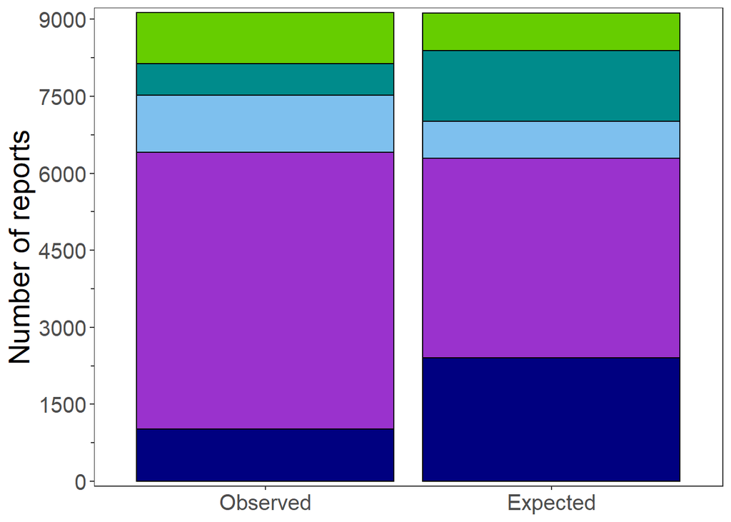

```r
# reports across habitat types
hab.observed = Coyotes %>%
  group_by(Habitat) %>%
  summarise(count=n()) %>%
  mutate(var = "Observed",
         perc = count,
         percentages = count/sum(count))

# empty data frame for adding expected avlues
hab.expected = Coyotes %>% group_by(Habitat) %>%
  summarise(count=n()) %>%
  mutate(perc = "none", var = "Expected", percentages = NA)

#

      # calculating expected percentages of reports, based on the area of that habitat type divided by the total area of the study area (minus water, which we are not considering in this analysis)
      hab.expected$perc = ifelse(hab.expected$Habitat =="Com100m", 146.7/556*9134, hab.expected$perc) # 146.7km square of commercial area within study MCP
      hab.expected$perc = ifelse(hab.expected$Habitat =="Mod100m", 83.8/556*9134, hab.expected$perc) # 83.8 square of modified open area within study MCP
      hab.expected$perc = ifelse(hab.expected$Habitat =="Mow100m", 43.6/556*9134, hab.expected$perc ) # 43.6 square of mowed area within study MCP
      hab.expected$perc = ifelse(hab.expected$Habitat =="Nat100m", 44.9/556*9134, hab.expected$perc ) # 44.9  square of natural area within study MCP
      hab.expected$perc = ifelse(hab.expected$Habitat =="Res100m", 236.5/556*9134, hab.expected$perc ) # 236.5km square of residential area within study MCP

# Joining together the two data frames
hab.totals = rbind(hab.observed, hab.expected) %>%
  mutate(var = fct_relevel(var, c("Observed", "Expected")),
         perc = as.numeric(perc),
         Habitat = recode(Habitat, Com100m ="Commercial", Mod100m = "Modified Open", Mow100m = "Mowed", Nat100m = "Natural",
                          Res100m = "Residential"))

hab.totals$Habitat = fct_relevel(hab.totals$Habitat, c("Natural", "Modified Open", "Mowed", "Residential", "Commercial"))

table.hab = matrix(c(1016, 614, 111, 997, 5456,
                     2419, 1377, 716, 738, 3885), ncol = 2)
colnames(table.hab) =c( "observed", "expected")
rownames(table.hab) = c( "com", "mod", "mow", "nat", "res")

hab.chsq = chisq.test(table.hab) # chi square test comparing observed and expected distribution of reports across habitat types

hab.chsq.resids = chisq.posthoc.test(table.hab, method = "holm") # run a posthoc test


# plotting
hab.plot =
  ggplot(hab.totals, aes(x=var, y= perc, fill = Habitat)) +
  geom_col(color="black") +
  theme_bw()+
  scale_fill_manual("Land Cover", values = c("chartreuse3", "cyan4", "skyblue2", "darkorchid3", "navy")) +
  ylab("Number of reports")+
  scale_y_continuous(expand = c(0.01, 0.01), guide = guide_prism_minor(), breaks = seq(0,9150, 1500)) +
  theme(axis.text.x = element_text(size = 15),
        axis.text.y=element_text(size = 15), axis.title.x = element_blank(),
        legend.title = element_text(size = 20), legend.text = element_text(size = 15), legend.key.size = unit(1, 'cm'),
        panel.grid.major = element_blank(), panel.grid.minor = element_blank(), axis.title.y= element_text(size = 20),
        legend.position = "none") +
  guides(fill = guide_legend(title.position = "top", title.hjust = 0))

hab.plot
```

```r
hab.chsq
```

```
##
##  Pearson's Chi-squared test
##
## data:  table.hab
## X-squared = 1564.4, df = 4, p-value < 2.2e-16
```

```r
save_plot("Figures/Habitat.reporting.patterns.jpeg", hab.plot, base_width = 3.2, base_height= 8)

rm(hab.expected, hab.totals, hab.observed, hab.plot, table.hab, hab.chsq)
```

## Figure 2. Temporal patterns in coyote reports

Reports over years - distribution divided into 4 month periods aligning with biological coyote seasons

```r
reporting.years = Coyotes %>%
  group_by(Time = floor_date(Date, "4 months"), Season) %>%
  summarise(count = n())
```

```r
reporting.years$Season = fct_relevel(reporting.years$Season, c("Breeding", "PupRearing", "Dispersal"))
reporting.years$Season = recode(reporting.years$Season, PupRearing = "Pup Rearing")

reporting.years.plot =
  ggplot(reporting.years, aes(x=Time, y= count, fill=Season)) +
  geom_bar(position="dodge", stat="identity", color="black") +
  theme_bw()+
  ylab("Number of reports")+ xlab("Year")+
  scale_fill_viridis(discrete = TRUE)+
 # scale_fill_manual(values = c("chartreuse3",  "skyblue2",  "navy")) +
  scale_y_continuous(expand = c(0.01,0.01), guide = guide_prism_minor()) +   scale_x_date(date_labels = "%Y", breaks="1 year", expand = c(0.01,0.01)) +
  theme(axis.title = element_text(size = 20), axis.text = element_text(size = 15),
        legend.title = element_text(size = 20), legend.text = element_text(size = 15), legend.key.size = unit(0.5, 'cm'),
        panel.grid.major = element_blank(), panel.grid.minor = element_blank(),
        legend.position = "top") +
  guides(fill = guide_legend(title.position = "top", title.hjust = 0.5))


rm(reporting.years)
```

Reports split into months - percentage values show % reports per month

```r
reporting.months = Coyotes %>%
  group_by(Month, Season) %>%
  summarise(count = n()) %>%
  mutate(Month = as.factor(Month)) %>%
  mutate(Month = recode(Month, '1'="Jan", '2'="Feb", '3'="Mar", '4'="Apr", '5'="May", '6'="Jun", '7'="Jul", '8'="Aug", '9'="Sep", '10'="Oct", '11'="Nov", '12'="Dec"))
```

```r
reporting.months$Season = fct_relevel(reporting.months$Season, c("Breeding", "PupRearing", "Dispersal"))
reporting.months$Season = recode(reporting.months$Season, PupRearing = "Pup Rearing")


reporting.months$percentage = reporting.months$count/sum(reporting.months$count)*100

reporting.month.plot =
  ggplot(reporting.months, aes(x=Month, y= percentage, fill=Season)) +
  geom_bar(position="dodge", stat="identity", color="black") +
  theme_bw()+
  ylab("Percentage of Reports") + geom_vline(xintercept= c(4.5,8.5), linetype = 2)+
  geom_text(label = "Breeding", x=2.5, y = 17.2, size = 6, color="grey30")+
  geom_text(label = "Pup Rearing", x=6.55, y = 17.2, size = 6, color="grey30")+
  geom_text(label = "Dispersal", x=10.5, y = 17.2, size = 6, color="grey30")+
  scale_fill_viridis(discrete = TRUE) +
  scale_y_continuous(expand = c(0.01, 0.01), lim = c(0,18,5), guide = guide_prism_minor()) +
  theme(axis.title = element_text(size = 20), axis.text.y = element_text(size = 15),
        axis.text.x = element_text(size = 15),
        panel.grid.major = element_blank(), panel.grid.minor = element_blank(),
        legend.position = "none")


rm(reporting.months)
```

Reports diurnally - see methods for night and day classification details

```r
reporting.diurnal = Coyotes %>%
  group_by(NightDay) %>%
  summarise(count = n()) %>%
  mutate(var = "Time of Day")

reporting.diurnal.plot =
  ggplot(reporting.diurnal, aes(x=NightDay, y = count, fill=NightDay)) +
  geom_col( color="black") +
  theme_bw()+
  ylab("Number of reports")+ xlab("Time of Day") +
  scale_fill_manual(values = c("skyblue2",  "navy",  "chartreuse3")) +
  scale_y_continuous(expand = c(0.01, 0.01), guide = guide_prism_minor()) +
  theme(axis.title = element_text(size = 20), axis.text = element_text(size = 15),
        panel.grid.major = element_blank(), panel.grid.minor = element_blank(),
        legend.position = "none")

remove(reporting.diurnal)
```

Making a plot with all 3 of these temporal factors together:

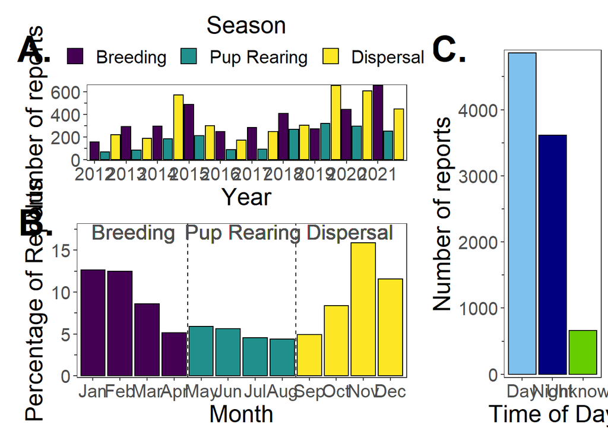

```r
reporting.patterns =
  ggdraw()+
  draw_plot(reporting.diurnal.plot, x= .7, y = 0, width =.3, height =0.9) + draw_plot_label(label = "C.", x=0.68, y=0.95, size = 30)+
  draw_plot(reporting.years.plot, x= 0.03, y = 0.5, width =.65, height =.5) + draw_plot_label(label = "A.", x=-0, y=0.95, size = 30)+
  draw_plot(reporting.month.plot, x= 0.03, y = 0, width =.65, height =.5) + draw_plot_label(label = "B.", x=0, y=0.55, size = 30)

reporting.patterns
```

```r
save_plot("Figures/Temporal.reporting.patterns.jpeg", reporting.patterns, base_width = 12, base_height= 8)


rm(reporting.diurnal.plot, reporting.years.plot, reporting.month.plot, reporting.patterns)
```

## Figure 3. Contextual Patterns in Coyote Reports

Looking at the number of reports classified into each of the contextual variables (human activity, vulnerable individuals, dog leash status, coyote # and coyote healt)

```r
# HUMAN ACTIVITY
act.reports = Coyotes %>%
  group_by(HumanActivity) %>%
  summarise(Count=n()) %>%
  mutate(Variable = "Human Activity",
         perc = Count/sum(Count)*100,
         HumanActivity = as.ordered(HumanActivity),
         Categories = HumanActivity) %>%
  mutate(Categories = fct_relevel(Categories, "Unknown", "HomeYard", "Driving", "Cycling", "OutdoorAct", "Walking"),
         Categories = recode(Categories, HomeYard = 'Home/Yard', OutdoorAct = 'Outdoor Activity')) %>%
    dplyr::select(c(Variable, Categories, Count, perc))

# VULNERABLE INDIVIDUALS
vul.reports = Coyotes %>%
  group_by(VulnerableIndividual) %>%
  summarise(Count=n()) %>%
  mutate(Variable = "Vulnerable Individual",
         perc = Count/sum(Count)*100,
         VulnerableIndividual = as.ordered(VulnerableIndividual)) %>%
  mutate(VulnerableIndividual = fct_relevel(VulnerableIndividual,  c("Unknown", "Multiple", "Child", "Dog", "Cat")),
         Categories = VulnerableIndividual) %>%
  dplyr::select(c(Variable, Categories, Count, perc))

#  Dog leash status
leash.reports = Coyotes %>% filter(DogPresent !="HomeYard") %>% filter(VulnerableIndividual =="Dog"| VulnerableIndividual =="Multiple")%>%
  group_by(DogPresent) %>%
  summarise(Count=n()) %>%
  mutate(Variable = "Dog Leash Status",
         perc = Count/sum(Count)*100,
         Categories = DogPresent,
  Categories = fct_relevel(Categories, "Unknown", "OffLeash", "Leashed"),
  Categories = recode(Categories, OffLeash = "Off-Leash")) %>%
  dplyr::select(c(Variable, Categories, Count, perc))

# Number of coyotes
num.reports = Coyotes %>%
  group_by(CoyoteNumber) %>%
  summarise(Count=n()) %>%
  mutate(Variable = "Number of Coyotes",
         perc = Count/sum(Count)*100,
         CoyoteNumber = as.ordered(CoyoteNumber)) %>%
  mutate(Categories = CoyoteNumber,
         Categories = fct_relevel(Categories,  c("Unknown", "More", "Three", "Two", "One"))) %>%
    dplyr::select(c(Variable, Categories, Count, perc))

# Coyote health
health.reports = Coyotes %>%
  group_by(Health) %>%
  summarise(Count=n()) %>%
  mutate(Variable = "Coyote Health") %>%
  mutate(Categories = Health,
         perc = Count/sum(Count)*100,
         Categories = as.factor(Categories)) %>%
  mutate(Categories = fct_relevel(Categories, c("Unknown", "Unhealthy","Healthy"))) %>%
    dplyr::select(c(Variable, Categories, Count, perc))


context.reports = rbind(act.reports, vul.reports, leash.reports, num.reports, health.reports)

context.reports$Variable = fct_relevel(context.reports$Variable, c("Human Activity", "Vulnerable Individual", "Dog Leash Status", "Number of Coyotes", "Coyote Health"))

context.plot.trends =
ggplot(context.reports, aes(y=Categories, x=perc, fill = Variable)) +
  geom_bar(stat="identity", position="dodge", color = "black") +
  scale_fill_viridis(discrete = TRUE)+
  geom_text(aes(x=-10, y = Categories, label = Count), hjust = 0.5)+
  geom_text(aes(x=-40, y = Categories, label = Categories), hjust =0.5)+
  xlab("Percentage of Reports")+ ylab(NULL)+
  scale_x_continuous(expand =c(0.4,0), breaks = seq(0,100, 20), guide = guide_prism_minor(), position = "top")+
  theme_classic()+
  theme(legend.position="none", axis.text.x= element_text(hjust = 0.5),
        axis.text.y = element_blank(), axis.ticks.y = element_blank(), axis.line.y=element_blank(), axis.title.y=element_blank())+
  facet_grid(Variable~., scale ="free_y", space="free_y")

save_plot("Figures/distribution_of_reports_across_contextual_vars.jpeg", context.plot.trends, base_width = 6, base_height= 6)

write.csv(context.reports,"Output_Tables/report_distrib_across_contexutal_vars.csv") # write that csv!


rm(act.reports, vul.reports, leash.reports, num.reports, health.reports)
```

## Table 1. Reports within each of the coyote boldness

```r
Coyotes %>%
  group_by(CoyoteResponse) %>%
  summarise(count=n()) %>%
  mutate(var = "Coyote Boldness",
         perc = count/sum(count)*100) %>%
  write.csv("Output_Tables/percentage_reports_in_boldness_categories.csv")

## number of cat depredations
nrow(Coyotes%>%filter(VulnerableIndividual == "Unknown", CoyoteResponse =="9"))
```

```
## [1] 4
```

## Table 2. Reports within each of the human concern categories

```r
Coyotes %>%
  group_by(HumanPerception) %>%
  summarise(count=n()) %>%
  mutate(var = "Human Concern",
         perc = count/sum(count)*100) %>%
    write.csv("Output_Tables/percentage_reports_in_concern_categories.csv")
```

## Figure 4. Changes in coyote boldness and human concern over years

```r
# making a data frame with percentages per year for BOLDNESS
bold.time = Coyotes %>%  filter(Bold != "Unknown", Bold!= "Sighting")%>%
  group_by(Year, Bold) %>%
  summarise(count=n())%>%
  mutate(perc = count/sum(count)*100,
         total = sum(count))
bold.time$Bold = factor(bold.time$Bold,
                        labels = c("Avoid.", "Indiff.", "Bold", "Aggres."))

# making a data frame with percentages of human perceptions per year
perc.time = Coyotes %>%  filter(HumanPerception != "Concern", HumanPerception!="Unknown") %>%
  group_by(Year,  HumanPerception) %>%
  summarise(count=n())%>%
  mutate(perc = count/sum(count)*100,
         total = sum(count)) %>%
  mutate(HumanPerception = fct_relevel(HumanPerception, c("Positive", "Neutral", "Negative")))
```

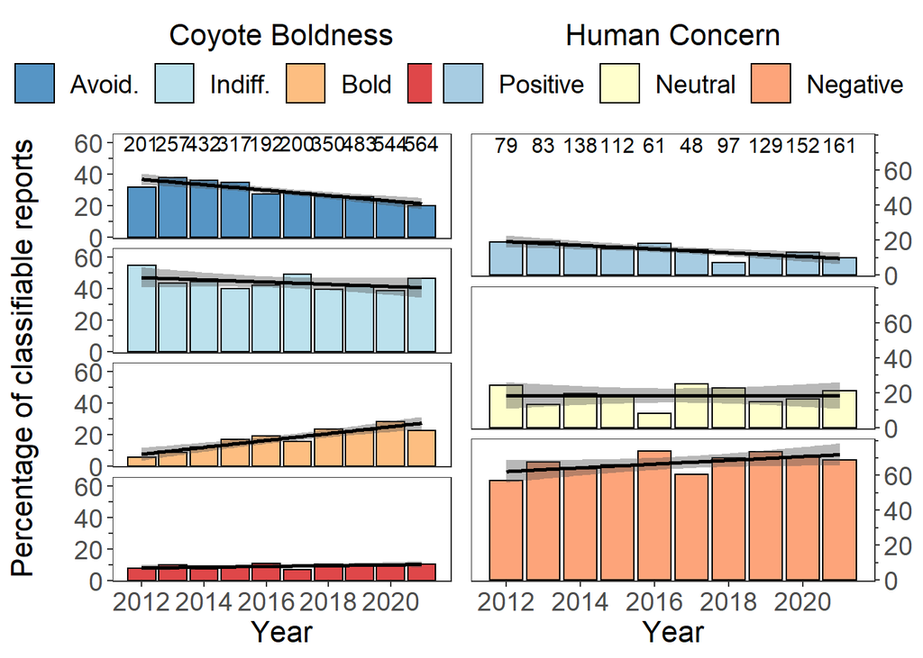

```r
# boldness plot
bold.time.plot =
  ggplot(bold.time, aes(x = Year, y = perc,  fill=Bold))+
  geom_bar(stat = "identity", position=position_dodge(), color = "black", alpha = 0.8) +
  theme_bw()+
  geom_smooth( method = "lm", color = "black", fill="grey30", size = 1)+
  scale_fill_brewer("Coyote Boldness", palette = "RdYlBu", direction=-1)+
  ylab("Percentage of classifiable reports\n")+
  scale_y_continuous(expand = c(0.01, 0.01), breaks = c(0,20,40, 60), limits = c(0,65), guide = guide_prism_minor()) + scale_x_continuous("Year", breaks = seq(2012, 2021, 2)) +
  theme(axis.title = element_text(size = 16), axis.text = element_text(size = 14),
        legend.title = element_text(size = 16), legend.text = element_text(size = 14), legend.key.size = unit(0.8, 'cm'),
        panel.grid.major = element_blank(), panel.grid.minor = element_blank(),
       legend.position ="top")+
  guides(fill = guide_legend(title.position = "top", title.hjust = 0.5, direction = "horizontal")) +
  facet_wrap(~Bold, nrow = 4)+
  theme(strip.background = element_blank(),
  strip.text.x = element_blank()) +
  geom_text(data =  data.frame(perc = 60, Year = c(2012:2021),
                        lab =subset(bold.time, Bold =="Avoid.")$total,
                   Bold = factor("Avoid.")), aes(label = lab), size = 4)


perc.time.plot =
  ggplot(perc.time, aes(x = Year, y = perc, fill=HumanPerception))+
  theme_bw() +
  geom_bar(stat = "identity", position=position_dodge(), color = "black", alpha =0.8) +
  geom_smooth( method = "lm", color = "black", fill="grey30", size = 1)+
  scale_fill_brewer("Human Concern", palette = "RdYlBu", direction=-1)+
        ylab(NULL)+
  scale_y_continuous(expand = c(0.01, 0.01), limits = c(0,80), breaks = c(0,20,40,60), position = "right", guide = guide_prism_minor()) +
  scale_x_continuous("Year", breaks = seq(2012, 2021, 2)) +
  theme(axis.title = element_text(size = 16), axis.text = element_text(size = 14),
        legend.title = element_text(size = 16), legend.text = element_text(size = 14), legend.key.size = unit(0.8, 'cm'),
        panel.grid.major = element_blank(), panel.grid.minor = element_blank(),
        legend.position = "top") +
  guides(fill = guide_legend(title.position = "top", title.hjust = 0.5, direction = "horizontal")) +
    facet_wrap(~HumanPerception, nrow = 3) +
  theme(strip.background = element_blank(),
  strip.text.x = element_blank())+
  geom_text(data =  data.frame(perc = 75, Year = c(2012:2021),
                        lab =subset(perc.time, HumanPerception =="Positive")$total,
                   HumanPerception = factor("Positive")), aes(label = lab), size = 4)

years.plot =
grid.arrange(bold.time.plot, perc.time.plot, nrow = 1)
```

```r
save_plot("Figures/boldness.concern.over.years.plot.jpeg", years.plot, base_width = 10, base_height= 10)

rm(bold.time, perc.time, bold.time.plot, perc.time.plot)
```

## Figure 5. Ordinal Regression top model outputs displayed in graphical format

### Coyote Boldness - Ordinal Regression Modelling

First, making a data frame with appropriate reports - excluding all reports that are sightings.

```r
bold.data = Coyotes %>%
  filter(Bold != "Unknown", Bold != "Sighting")
# consider also removing reports of cat depredations and reports where reporters are driving
```

Second, transform our compositional land cover variables using a centered log-ratio transformation

```r
bold.data.trans = bold.data

# for 100m buffer size
bold.data.trans[,c("Mod100m", "Mow100m", "Nat100m", "Water100m", "Com100m", "Res100m")] = compositions::clr(bold.data.trans[,c("Mod100m", "Mow100m", "Nat100m", "Water100m", "Com100m", "Res100m")]+1)

# for 200m buffer size
bold.data.trans[,c("Mod200m", "Mow200m", "Nat200m", "Water200m", "Com200m", "Res200m")] = compositions::clr(bold.data.trans[,c("Mod200m", "Mow200m", "Nat200m", "Water200m", "Com200m", "Res200m")]+1)

# for 400m buffer size
bold.data.trans[,c("Mod400m", "Mow400m", "Nat400m", "Water400m", "Com400m", "Res400m")] = compositions::clr(bold.data.trans[,c("Mod400m", "Mow400m", "Nat400m", "Water400m", "Com400m", "Res400m")]+1)

# for 800m buffer size
bold.data.trans[,c("Mod800m", "Mow800m", "Nat800m", "Water800m", "Com800m", "Res800m")] = compositions::clr(bold.data.trans[,c("Mod800m", "Mow800m", "Nat800m", "Water800m", "Com800m", "Res800m")]+1)

# for 1600m buffer size
bold.data.trans[,c("Mod1600m", "Mow1600m", "Nat1600m", "Water1600m", "Com1600m", "Res1600m")] = compositions::clr(bold.data.trans[,c("Mod1600m", "Mow1600m", "Nat1600m", "Water1600m", "Com1600m", "Res1600m")]+1)

rm(bold.data)
```

#### (Appendix 4 Table 2) Third, we select the best-fit scale using univariate ordinal regressions. Based on the AIC values of univariate models, the best scales are Build200m, Res100m, Mod400m, Nat100m, Mow100m, Com200m

```r
bold.scale_models <- list()

for(i in c(1:5)){ # For each of your five scales (100, 200, 400, 800, 1600)
  # Define the variables you want to test.
  if(i==1){scales <- c("Mod100m", "Mow100m", "Nat100m", "Com100m", "Res100m", "Build100m", "RoadDistDecay")}
  if(i==2){scales <- c("Mod200m", "Mow200m", "Nat200m", "Com200m", "Res200m", "Build200m")}
  if(i==3){scales <- c("Mod400m", "Mow400m", "Nat400m", "Com400m", "Res400m", "Build400m")}
  if(i==4){scales <- c("Mod800m", "Mow800m", "Nat800m", "Com800m", "Res800m", "Build800m")}
  if(i==5){scales <- c("Mod1600m", "Mow1600m", "Nat1600m", "Com1600m", "Res1600m", "Build1600m")}


  # Create a data frame to store the results from all the models.
  bold.scale_models[[i]] <- data.frame()

  # For every variable you want to test:
  for(j in c(scales)){

    model <- clm(Bold ~ bold.data.trans[,j], # Create the predictive model
                  data=bold.data.trans)

    null <- clm(Bold ~ 1, # Create the null model
                  data=bold.data.trans)

    bold.scale_models[[i]][j,1] <- j # First column is the predictor
    bold.scale_models[[i]][j,2] <- AIC(model) # Second column is AIC
    bold.scale_models[[i]][j,3] <-  AIC(model) - AIC(null) # Second column is delta AIC from null mod



  }

  colnames(bold.scale_models[[i]]) <- c("predictor", "AIC", "deltaAIC")
  rm(model, scales) # Keep workspace clean
}

bold.scale.model.outputs <- dplyr::bind_rows(bold.scale_models)

write.csv(bold.scale.model.outputs, "Output_Tables/coyote_boldness_univariate_scale_mods.csv") # write csv


rm(bold.scale_models, bold.scale.model.outputs, null)
```

#### (Appendix 4 Table 3) Fourth, we evaluate correlations between our variables using R-squared tests. Strong correlations between building density/road dist decay and Res100m. So, because res100m has the bigger (worst) AIC value, we remove it from analyses going forward. We also write a .csv file with corr output.

```r
bold.correlations = rcorr(as.matrix(bold.data.trans[,c("RoadDistDecay", "Mod400m", "Nat100m", "Mow100m", "Build200m", "Com200m", "Res100m")]), type = c("spearman"))

write.csv(bold.correlations$r, "Output_Tables/bold_correlation_coefficients.csv")

rm(bold.correlations)
```

Finally, we construct full models and select the most parsimonious models using AIC

```r
# First, we scale and center all variables, also renaming them for ease of interpretation and plotting.
bold.data.modelling = bold.data.trans %>%
  mutate(Road_Distance_Decay = scale(RoadDistDecay, scale= TRUE, center = TRUE),
         Natural = scale(Nat100m, center = TRUE, scale = TRUE),
         Modified_Open = scale(Mod400m, center = TRUE, scale = TRUE),
         Mowed = scale(Mow100m, center = TRUE, scale = TRUE),
         Commercial =  scale(Com200m, center = TRUE, scale = TRUE),
         Building_Density = scale(Build200m, center = TRUE, scale = TRUE),
         Year = scale(Year_int, scale = TRUE, center = TRUE))

bold.model.null = clm(Bold ~ 1, data = bold.data.modelling) # Null model (for calculating AIC differ)

# first, construct model without year
bold.model.base = clm(Bold ~ Road_Distance_Decay + Natural + Modified_Open + Mowed + Commercial + Building_Density + Season +
                        Road_Distance_Decay*Season + Natural*Season + Modified_Open*Season + Mowed*Season +
                        Commercial*Season + Building_Density*Season,
                      data = bold.data.modelling, na.action = "na.fail")
AIC(bold.model.base)- AIC(bold.model.null)
```

```
## [1] -149.2072
```

```r
summary(bold.model.base)
```

```
## formula:
## Bold ~ Road_Distance_Decay + Natural + Modified_Open + Mowed + Commercial + Building_Density + Season + Road_Distance_Decay * Season + Natural * Season + Modified_Open * Season + Mowed * Season + Commercial * Season + Building_Density * Season
## data:    bold.data.modelling
##
##  link  threshold nobs logLik   AIC     niter max.grad cond.H
##  logit flexible  3540 -4361.06 8768.12 5(0)  1.60e-10 1.1e+02
##
## Coefficients:
##                                      Estimate Std. Error z value Pr(>|z|)
## Road_Distance_Decay                  -0.14937    0.06338  -2.357 0.018439 *
## Natural                              -0.08796    0.07140  -1.232 0.217979
## Modified_Open                        -0.04477    0.06323  -0.708 0.478967
## Mowed                                 0.08034    0.06054   1.327 0.184449
## Commercial                           -0.01594    0.05072  -0.314 0.753307
## Building_Density                     -0.16113    0.06938  -2.322 0.020218 *
## SeasonDispersal                       0.03318    0.07059   0.470 0.638318
## SeasonPupRearing                      0.60627    0.08631   7.025 2.15e-12 ***
## Road_Distance_Decay:SeasonDispersal  -0.02068    0.08969  -0.231 0.817633
## Road_Distance_Decay:SeasonPupRearing  0.16568    0.09966   1.662 0.096430 .
## Natural:SeasonDispersal               0.04247    0.09865   0.431 0.666818
## Natural:SeasonPupRearing              0.16093    0.11161   1.442 0.149308
## Modified_Open:SeasonDispersal         0.15431    0.08666   1.781 0.074960 .
## Modified_Open:SeasonPupRearing        0.39790    0.10271   3.874 0.000107 ***
## Mowed:SeasonDispersal                 0.02595    0.08261   0.314 0.753435
## Mowed:SeasonPupRearing               -0.04252    0.10523  -0.404 0.686157
## Commercial:SeasonDispersal           -0.08513    0.07148  -1.191 0.233633
## Commercial:SeasonPupRearing           0.11082    0.08390   1.321 0.186506
## Building_Density:SeasonDispersal      0.10432    0.09610   1.086 0.277685
## Building_Density:SeasonPupRearing    -0.02578    0.12254  -0.210 0.833379
## ---
## Signif. codes:  0 '***' 0.001 '**' 0.01 '*' 0.05 '.' 0.1 ' ' 1
##
## Threshold coefficients:
##                       Estimate Std. Error z value
## Avoidance|Indifferent -0.83009    0.05541  -14.98
## Indifferent|Bold       1.09470    0.05703   19.19
## Bold|Aggressive        2.50724    0.07392   33.92
```

```r
bold.model.base.dredge = dredge(bold.model.base) # dredging base models to get top base models
```

```
## Fixed term is "(Intercept)"
```

```r
bold.model.base.dredge.coefs <- model.avg(bold.model.base.dredge, subset=delta < 2) # get the top model
summary(bold.model.base.dredge.coefs) # see all coefs
```

```
##
## Call:
## model.avg(object = bold.model.base.dredge, subset = delta < 2)
##
## Component model call:
## clm(formula = Bold ~ <6 unique rhs>, data = bold.data.modelling,
##      na.action = na.fail)
##
## Component models:
##                 df   logLik    AICc delta weight
## 1/3/4/6/7/9     11 -4368.37 8758.82  0.00   0.30
## 1/2/3/4/6/7/8/9 14 -4365.89 8759.90  1.09   0.17
## 1/3/4/6/7/9/10  13 -4367.04 8760.19  1.37   0.15
## 1/2/3/4/6/7/9   12 -4368.16 8760.41  1.59   0.13
## 1/3/4/5/6/7/9   12 -4368.24 8760.58  1.76   0.12
## 1/3/4/6/7/9/11  13 -4367.28 8760.66  1.84   0.12
##
## Term codes:
##           Building_Density                 Commercial
##                          1                          2
##              Modified_Open                      Mowed
##                          3                          4
##                    Natural        Road_Distance_Decay
##                          5                          6
##                     Season          Commercial:Season
##                          7                          8
##       Modified_Open:Season               Mowed:Season
##                          9                         10
## Road_Distance_Decay:Season
##                         11
##
## Model-averaged coefficients:
## (full average)
##                                        Estimate Std. Error Adjusted SE z value
## Avoidance|Indifferent                -8.306e-01  5.521e-02   5.523e-02  15.038
## Indifferent|Bold                      1.088e+00  5.677e-02   5.679e-02  19.160
## Bold|Aggressive                       2.498e+00  7.370e-02   7.373e-02  33.886
## Building_Density                     -1.113e-01  3.860e-02   3.862e-02   2.883
## Modified_Open                        -1.283e-02  5.655e-02   5.657e-02   0.227
## Mowed                                 9.944e-02  3.852e-02   3.854e-02   2.580
```

[output cut: 62 more lines]

```
## Road_Distance_Decay                   0.00612 **
## SeasonDispersal                       0.59611
## SeasonPupRearing                      < 2e-16 ***
## Modified_Open:SeasonDispersal         0.10587
## Modified_Open:SeasonPupRearing       4.59e-05 ***
## Commercial                            0.74498
## Commercial:SeasonDispersal            0.24437
## Commercial:SeasonPupRearing           0.27284
## Mowed:SeasonDispersal                 0.91273
## Mowed:SeasonPupRearing                0.15693
## Natural                               0.61537
## Road_Distance_Decay:SeasonDispersal   0.99695
## Road_Distance_Decay:SeasonPupRearing  0.18583
## ---
## Signif. codes:  0 '***' 0.001 '**' 0.01 '*' 0.05 '.' 0.1 ' ' 1
```

```r
bold.model.base.dredge.variables <- get.models(bold.model.base.dredge, subset=delta ==0) # get the top model
summary(bold.model.base.dredge.variables[["622"]]) # see which coefficients were significant in the top model
```

```
## formula:
## Bold ~ Building_Density + Modified_Open + Mowed + Road_Distance_Decay + Season + Modified_Open:Season + 1
## data:    bold.data.modelling
##
##  link  threshold nobs logLik   AIC     niter max.grad cond.H
##  logit flexible  3540 -4368.37 8758.74 5(0)  1.21e-10 3.1e+01
##
## Coefficients:
##                                Estimate Std. Error z value Pr(>|z|)
## Building_Density               -0.11083    0.03750  -2.955  0.00312 **
## Modified_Open                  -0.01192    0.05606  -0.213  0.83156
## Mowed                           0.09796    0.03346   2.928  0.00341 **
## Road_Distance_Decay            -0.10814    0.03713  -2.912  0.00359 **
## SeasonDispersal                 0.03796    0.07027   0.540  0.58907
## SeasonPupRearing                0.62018    0.08539   7.263 3.79e-13 ***
## Modified_Open:SeasonDispersal   0.11911    0.07296   1.633  0.10255
## Modified_Open:SeasonPupRearing  0.34532    0.08279   4.171 3.03e-05 ***
## ---
## Signif. codes:  0 '***' 0.001 '**' 0.01 '*' 0.05 '.' 0.1 ' ' 1
##
## Threshold coefficients:
##                       Estimate Std. Error z value
## Avoidance|Indifferent -0.83005    0.05517  -15.04
## Indifferent|Bold       1.08797    0.05674   19.18
## Bold|Aggressive        2.49798    0.07368   33.90
```

```r
# variables for global model: Build200m, Mod400m, Mow100m, RoadDistDecay, Season, Com200m, Nat100m,
# interactions for global: Mow100m*Season, Mod400m*Season, RoadDistDecay*Season
# include YEAR in the global mod for NOW

# interactions only for variables with significant effects in base models
bold.model.global = clm(Bold ~ Road_Distance_Decay + Natural + Modified_Open + Mowed + Commercial + Building_Density + Season +
                        Road_Distance_Decay*Season + Modified_Open*Season + Mowed*Season +
                        Commercial*Season  +
                          Year +
                          Road_Distance_Decay*Year + Mowed*Year + Building_Density*Year + Modified_Open*Season*Year, # interactions with year
                      data = bold.data.modelling, na.action = "na.fail")

AIC(bold.model.global) - AIC(bold.model.null)
```

```
## [1] -221.8929
```

```r
bold.model.global.dredge = dredge(bold.model.global)# dredge the global model
```

```
## Fixed term is "(Intercept)"
```

```r
bold.models.list = get.models(bold.model.global.dredge, subset = delta < 2) # get the list of top global models

# putting together a data frame with the outputs of all the top models
list_for_model_coeffs <- list()

for(i in c(1:length(bold.models.list))){ # For every model in your list of models...

list_for_model_coeffs[[i]] <- data.frame(
    conf_2.5 = confint(bold.models.list[[i]], level=0.95)[,1], # getting 2.5% confint
    odds = coef(bold.models.list[[i]])[-c(1:3)], # getting coefficient
    conf_97.5 = confint(bold.models.list[[i]], level=0.95)[,2], # getting 97.5 confint
    variable = names(coef(bold.models.list[[i]]))[-c(1:3)], # getting the variable name
    AIC = as.factor(AIC(bold.models.list[[i]]))) # aic for model

}

mod.outputs.bold = dplyr::bind_rows(list_for_model_coeffs)


rm(bold.data.modelling, bold.models.list, bold.model.global, bold.model.base.dredge.coefs, bold.model.base.dredge.variables, bold.model.base, bold.models.list)
```

#### (Appendix 4 Table 5) Writing a CSV with coefficients, confidence intervals (95%), AIC, deltaAIC, weights, and k for each of the models that made it within 2 AIC points of the top model

```r
mod.outputs.bold %>%
  mutate(coef_confint = paste(round(odds, 2), # combining coefficients and confidence intervals into one column
                              gsub(" ","", paste("(",round(conf_2.5, 2),",",round(conf_97.5,2), ")")))) %>%
  pivot_wider(id_col=AIC, names_from=variable, values_from = coef_confint) %>%
  mutate(delta = round(bold.model.global.dredge[1:20,]$delta, 2),# add # parameters to model
         k =bold.model.global.dredge[1:20,]$df, # add delta AIC to model
         weight = round(bold.model.global.dredge[1:20,]$weight, 2)) %>% # add AIC weights to model
  write.csv("Output_Tables/coyote_boldness_regression_outputs.csv") # write csv with model outputs for all top models

rm(bold.model.global.dredge)
```

### Human Concern - Ordinal Regression Modelling

First, making a data frame with appropriate reports - excluding all reports that have no human perceptions mentioned.

```r
perc.data = Coyotes %>%
  filter(HumanPerception != "Unknown", HumanPerception != "Concern")%>%
  mutate(HumanPerception = as.ordered(HumanPerception),
         HumanPerception = fct_relevel(HumanPerception, c("Positive", "Neutral", "Negative")))
```

Second, transform our compositional land cover variables using a centered log-ratio transformation

```r
perc.data.trans = perc.data

# for 100m buffer size
perc.data.trans[,c("Mod100m", "Mow100m", "Nat100m", "Water100m", "Com100m", "Res100m")] = compositions::clr(perc.data.trans[,c("Mod100m", "Mow100m", "Nat100m", "Water100m", "Com100m", "Res100m")]+1)

# for 200m buffer size
perc.data.trans[,c("Mod200m", "Mow200m", "Nat200m", "Water200m", "Com200m", "Res200m")] = compositions::clr(perc.data.trans[,c("Mod200m", "Mow200m", "Nat200m", "Water200m", "Com200m", "Res200m")]+1)

# for 400m buffer size
perc.data.trans[,c("Mod400m", "Mow400m", "Nat400m", "Water400m", "Com400m", "Res400m")] = compositions::clr(perc.data.trans[,c("Mod400m", "Mow400m", "Nat400m", "Water400m", "Com400m", "Res400m")]+1)

# for 800m buffer size
perc.data.trans[,c("Mod800m", "Mow800m", "Nat800m", "Water800m", "Com800m", "Res800m")] = compositions::clr(perc.data.trans[,c("Mod800m", "Mow800m", "Nat800m", "Water800m", "Com800m", "Res800m")]+1)

# for 1600m buffer size
perc.data.trans[,c("Mod1600m", "Mow1600m", "Nat1600m", "Water1600m", "Com1600m", "Res1600m")] = compositions::clr(perc.data.trans[,c("Mod1600m", "Mow1600m", "Nat1600m", "Water1600m", "Com1600m", "Res1600m")]+1)

rm(perc.data)
```

#### (Appendix 4 Table 2) Third, we select the best-fit scale using univariate ordinal regressions. Based on the AIC values of univariate models, the best scales are Res800m, Mod1600m, Nat1600m, Com100m, Mow800m. We removed RoadDistDecay and Building density as their AIC values were worse than the null model

```r
perc.scale.models <- list()

for(i in c(1:5)){ # For each of your five scales (100, 200, 400, 800, 1600)
  # Define the variables you want to test.
  if(i==1){scales <- c("Mod100m", "Mow100m", "Nat100m", "Com100m", "Res100m", "Build100m", "RoadDistDecay")}
  if(i==2){scales <- c("Mod200m", "Mow200m", "Nat200m", "Com200m", "Res200m", "Build200m")}
  if(i==3){scales <- c("Mod400m", "Mow400m", "Nat400m", "Com400m", "Res400m", "Build400m")}
  if(i==4){scales <- c("Mod800m", "Mow800m", "Nat800m", "Com800m", "Res800m", "Build800m")}
  if(i==5){scales <- c("Mod1600m", "Mow1600m", "Nat1600m", "Com1600m", "Res1600m", "Build1600m")}


  # Create a data frame to store the results from all the models.
  perc.scale.models[[i]] <- data.frame()

  # For every variable you want to test:
  for(j in c(scales)){

    model <- clm(HumanPerception ~ perc.data.trans[,j], # Create the predictive model
                  data=perc.data.trans)

    null <- clm(HumanPerception ~1, # Create the null model
                  data=perc.data.trans)


    perc.scale.models[[i]][j,1] <- j # First column is the predictor
    perc.scale.models[[i]][j,2] <- AIC(model) # Second column is AIC
    perc.scale.models[[i]][j,3] <- AIC(model)-AIC(null) # third col is delta AIC compared to null


  }

  colnames(perc.scale.models[[i]]) <- c("predictor", "AIC", "deltaAIC")
  rm(model, scales) # Keep workspace clean
}

perc.scale.models.outputs <- dplyr::bind_rows(perc.scale.models)

write.csv(perc.scale.models.outputs, "Output_Tables/human_concern_univariate_scale_mods.csv") # write csv

rm(perc.scale.models, perc.scale.models.outputs)
```

#### (Appendix 4 Table 4) Fourth, we evaluate correlations between our variables using R-squared tests. No big corrs. We also briefly write a csv file with our correlation ouptut.

```r
concern.correlations = rcorr(as.matrix(perc.data.trans[,c("Mod1600m", "Mow800m", "Nat1600m", "Com100m", "Res800m")]), type = c("spearman"))

write.csv(concern.correlations$r, "Output_Tables/concern_correlation_coefficients.csv")

rm(concern.correlations)
```

Fifth, we construct full models and select the most parsimonious models using AIC

```r
# First, we scale and center all variables, also renaming them for ease of interpretation and plotting.
perc.data.modelling = perc.data.trans %>%
  mutate(Natural = scale(Nat1600m, center = TRUE, scale = TRUE),
         Modified_Open = scale(Mod1600m, center = TRUE, scale = TRUE),
         Mowed = scale(Mow800m, center = TRUE, scale = TRUE),
         Commercial =  scale(Com100m, center = TRUE, scale = TRUE),
         Residential = scale(Res800m, center = TRUE, scale = TRUE),
         Year = scale(Year_int, scale = TRUE, center = TRUE))

perc.model.null = clm(HumanPerception ~ 1, data = perc.data.modelling)

# construct model without year
perc.model.base = clm(HumanPerception ~ Natural + Modified_Open + Mowed + Commercial + Residential + Season +
                        Natural*Season + Modified_Open*Season + Mowed*Season + Commercial*Season + Residential*Season,
                      data = perc.data.modelling, na.action = "na.fail")

AIC(perc.model.base) - AIC(perc.model.null)
```

```
## [1] 2.139187
```

```r
perc.model.base.dredge = dredge(perc.model.base) # dredge to get the top models
```

```
## Fixed term is "(Intercept)"
```

```r
perc.model.base.dredge.coefs <- model.avg(perc.model.base.dredge, subset=delta < 2) # get the top models
summary(perc.model.base.dredge.coefs) # see the variables that made it into the top models
```

```
##
## Call:
## model.avg(object = perc.model.base.dredge, subset = delta < 2)
##
## Component model call:
## clm(formula = HumanPerception ~ <15 unique rhs>, data =
##      perc.data.modelling, na.action = na.fail)
##
## Component models:
##        df  logLik    AICc delta weight
## 256     6 -890.89 1793.86  0.00   0.12
## 2356    7 -890.18 1794.47  0.61   0.09
## 1346    7 -890.26 1794.62  0.76   0.08
## 2456    7 -890.27 1794.64  0.77   0.08
## 25      4 -893.52 1795.07  1.21   0.07
## 23456   8 -889.48 1795.10  1.23   0.07
## 134     5 -892.63 1795.32  1.45   0.06
## 12346   8 -889.59 1795.32  1.46   0.06
## 356     6 -891.65 1795.37  1.51   0.06
## 13467   9 -888.61 1795.38  1.52   0.06
## 1256    7 -890.74 1795.59  1.73   0.05
## 13456   8 -889.73 1795.60  1.73   0.05
## 235     5 -892.78 1795.61  1.75   0.05
## 12456   8 -889.78 1795.70  1.84   0.05
## 123456  9 -888.79 1795.74  1.88   0.05
##
## Term codes:
##        Commercial     Modified_Open             Mowed           Natural
##                 1                 2                 3                 4
##       Residential            Season Commercial:Season
##                 5                 6                 7
##
## Model-averaged coefficients:
## (full average)
##                              Estimate Std. Error Adjusted SE z value Pr(>|z|)
## Positive|Neutral            -1.711698   0.129405    0.129518  13.216   <2e-16
## Neutral|Negative            -0.611308   0.116668    0.116761   5.236    2e-07
## Modified_Open                0.096084   0.090560    0.090605   1.060    0.289
## Residential                  0.119762   0.096815    0.096857   1.236    0.216
## SeasonDispersal              0.270966   0.184083    0.184195   1.471    0.141
```

[output cut: 31 more lines]

```
## Commercial:SeasonPupRearing  0.28890    0.16238     0.16257   1.777   0.0756
##
## Positive|Neutral            ***
## Neutral|Negative            ***
## Modified_Open               .
## Residential                 *
## SeasonDispersal             *
## SeasonPupRearing
## Mowed                       .
## Commercial
## Natural
## Commercial:SeasonDispersal
## Commercial:SeasonPupRearing .
## ---
## Signif. codes:  0 '***' 0.001 '**' 0.01 '*' 0.05 '.' 0.1 ' ' 1
```

```r
perc.model.base.dredge.variables <- get.models(perc.model.base.dredge, subset=delta ==0) # get the top model
summary(perc.model.base.dredge.variables[["51"]]) # see which coefficients made it into the top models WITH sig effects
```

```
## formula: HumanPerception ~ Modified_Open + Residential + Season + 1
## data:    perc.data.modelling
##
##  link  threshold nobs logLik  AIC     niter max.grad cond.H
##  logit flexible  1060 -890.89 1793.78 5(0)  8.95e-11 2.2e+01
##
## Coefficients:
##                  Estimate Std. Error z value Pr(>|z|)
## Modified_Open     0.16495    0.06853   2.407  0.01609 *
## Residential       0.19142    0.06372   3.004  0.00266 **
## SeasonDispersal   0.33609    0.14774   2.275  0.02291 *
## SeasonPupRearing  0.19932    0.17215   1.158  0.24692
## ---
## Signif. codes:  0 '***' 0.001 '**' 0.01 '*' 0.05 '.' 0.1 ' ' 1
##
## Threshold coefficients:
##                  Estimate Std. Error z value
## Positive|Neutral  -1.6763     0.1174 -14.283
## Neutral|Negative  -0.5767     0.1024  -5.633
```

```r
# no interaction terms!!


# variables for global model: Build200m, Mod1600m, Mow800m, RoadDistDecay, Season, Com100m, Nat1600m, Res800m
# include YEAR in the global mod
# interactions between year and the following: Modified_Open, Residential, Road_Distance_Decay

# interactions only if significant effects existed in base model
perc.model.global = clm(HumanPerception ~  Natural + Modified_Open + Mowed + Commercial + Residential + Season +
                          Year +  Modified_Open*Year + Residential*Year,
                      data = perc.data.modelling, na.action = "na.fail")
AIC(perc.model.global) - AIC(perc.model.null)
```

```
## [1] -13.15169
```

```r
summary(perc.model.global)
```

```
## formula:
## HumanPerception ~ Natural + Modified_Open + Mowed + Commercial + Residential + Season + Year + Modified_Open * Year + Residential * Year
## data:    perc.data.modelling
##
##  link  threshold nobs logLik  AIC     niter max.grad cond.H
##  logit flexible  1060 -883.68 1791.35 5(0)  5.90e-11 2.2e+01
##
## Coefficients:
##                    Estimate Std. Error z value Pr(>|z|)
## Natural            -0.10684    0.07415  -1.441   0.1496
## Modified_Open       0.10717    0.07803   1.373   0.1696
## Mowed              -0.08375    0.07206  -1.162   0.2451
## Commercial         -0.10137    0.07401  -1.370   0.1708
## Residential         0.07744    0.08166   0.948   0.3430
## SeasonDispersal     0.31427    0.14884   2.112   0.0347 *
## SeasonPupRearing    0.17090    0.17315   0.987   0.3236
## Year                0.12581    0.06579   1.912   0.0559 .
## Modified_Open:Year -0.08522    0.06960  -1.224   0.2208
## Residential:Year   -0.13304    0.06448  -2.063   0.0391 *
## ---
## Signif. codes:  0 '***' 0.001 '**' 0.01 '*' 0.05 '.' 0.1 ' ' 1
##
## Threshold coefficients:
##                  Estimate Std. Error z value
## Positive|Neutral  -1.7200     0.1189 -14.460
## Neutral|Negative  -0.6058     0.1037  -5.844
```

```r
perc.model.global.dredge = dredge(perc.model.global) # dredging to get the models
```

```
## Fixed term is "(Intercept)"
```

```r
perc.models.list = get.models(perc.model.global.dredge, subset = delta < 2) # 42 top models

# putting together a data frame with the outputs of all the top models
list_for_model_coeffs <- list()

for(i in c(1:length(perc.models.list))){ # For every model in your list of models...

list_for_model_coeffs[[i]] <- data.frame(
    conf_2.5 = confint(perc.models.list[[i]], level=0.95)[,1], # getting 2.5% confint
    odds = coef(perc.models.list[[i]])[-c(1:2)], # getting coefficient
    conf_97.5 = confint(perc.models.list[[i]], level=0.95)[,2], # getting 97.5 confint
    variable = names(coef(perc.models.list[[i]]))[-c(1:2)], # getting the variable name
    AIC = as.factor(AIC(perc.models.list[[i]]))) # aic for model

}

mod.outputs.perc = dplyr::bind_rows(list_for_model_coeffs)

rm(perc.model.base, perc.model.base.dredge, perc.model.base.dredge.coefs, perc.model.base.dredge.variables, perc.model.global,  perc.models.list)
```

#### (Appendix 4 Table 7) Writing a CSV with coefficients, confidence intervals (95%), AIC, deltaAIC, weights, and k for each of the models that made it within 2 AIC points of the top model

```r
mod.outputs.perc %>%
  mutate(coef_confint = paste(round(odds,5), # combining coefficients and confidence intervals into one column
                              gsub(" ","", paste("(",round(conf_2.5,5),", ",round(conf_97.5,5), ")")))) %>%
  pivot_wider(id_col=AIC, names_from=variable, values_from = coef_confint) %>%
  mutate(delta = perc.model.global.dredge[1:20,]$delta, # add delta AIC to model
         k =perc.model.global.dredge[1:20,]$df, #  add # parameters to model
         weight = perc.model.global.dredge[1:20,]$weight, ) %>% # add AIC weights to model
  write.csv("Output_Tables/human_concern_regression_outputs.csv") # write csv with model outputs for all top models

rm(perc.model.global.dredge)
```

### Final plot for ordinal regression models (Figure 5)

Now we’ll make a plot with results from both variables in the output

```r
bold.output.top.mod = subset(mod.outputs.bold, AIC == "8677.58118627508") # make a data frame with the top model output for graphing
bold.output.top.mod$response = "Coyote Boldness"
perc.output.top.mod = subset(mod.outputs.perc, AIC == "1788.86543070063") # make a data frame with the top model output for graphing
perc.output.top.mod$response = "Human Concern"

ordinal.outputs = rbind(bold.output.top.mod, perc.output.top.mod)

ordinal.outputs$variable = factor(ordinal.outputs$variable,
                               levels = c( "Modified_Open:SeasonDispersal", "Modified_Open:SeasonPupRearing",
                                          "Modified_Open","Mowed","Residential:Year", "Residential", "Building_Density", "Road_Distance_Decay",
                                          "SeasonDispersal","SeasonPupRearing",
                                          "Year"),
                               labels = c( "Modified Open:Dispersal Season","Modified Open:Pup Rearing Season",
                                          "Modified Open","Mowed","Residential:Year", "Residential","Building Density", "Road Distance Decay",
                                          "Dispersal Season", "Pup Rearing Season", "Year"))

ordinal.output.plot =
ggplot(ordinal.outputs, aes(y=odds, x=variable)) +
  geom_point(position=position_dodge(0.6), size=3)+
  ylab("\nLog Odds of Increase in Ordinal Scale (95% CI)") + xlab("Explanatory Variable") +
  geom_errorbar(position = position_dodge(0.6), aes(x=variable, ymin=conf_2.5, ymax=conf_97.5), width = 0, size = 1) +
  scale_color_manual(values =c("black", "black", "black", "black", "black", "black", "black", "black")) +
  theme_bw()+
  geom_hline(yintercept = 0, linetype="dashed") +
  theme(axis.text=element_text(size=14), axis.title=element_text(size=16, face="bold"),
        panel.grid = element_blank()) +
  facet_wrap(~response, scales = "free_x") +
  theme(strip.text = element_text(size = 16, face = "bold"),
        strip.background = element_rect(fill= "white")) +
  coord_flip()

save_plot("Figures/ordinal.regression.outputs.jpeg", ordinal.output.plot, base_width = 10, base_height= 6)

rm(mod.outputs.bold, mod.outputs.perc, bold.output.top.mod, perc.output.top.mod, ordinal.outputs, ordinal.output.plot)
```

## Figure 6. Contextual variables associated with coyote boldness and human concern

For this analysis, we use chi square tests then look at Pearson’s chi square residuals to discern which categories within each of the contextual variables are most strongly related to each of the coyote boldness or human concern categories

### Coyote boldness across contextual variables

Coyote boldness across human activity

```r
bold.act.table = table(Coyotes$Bold, Coyotes$HumanActivity) # make a table

bold.act.chsq = chisq.test(bold.act.table[3:6,c(1, 2,3,4,6)]) # run a chi square test
bold.act.chsq$expected
```

```
##
##                 Cycling   Driving  HomeYard OutdoorAct  Walking
##   Avoidance   15.959145 115.35382 168.55097   34.99813 412.1379
##   Indifferent 23.308471 168.47526 246.17016   51.11507 601.9310
##   Bold        12.455397  90.02849 131.54648   27.31447 321.6552
##   Aggressive   5.276987  38.14243  55.73238   11.57234 136.2759
```

```r
bold.act.chsq.resids = chisq.posthoc.test(bold.act.table[3:6,c(1, 2,3,4,5,6)], method = "holm") # run a posthoc test


# formatting a new data frame
bold.act.chsq.resids.long = pivot_longer(bold.act.chsq.resids, cols = c(Cycling, Driving, HomeYard, OutdoorAct,Unknown, Walking))
bold.act.chsq.resids.long = data.frame(Bold = subset(bold.act.chsq.resids.long, Value =="Residuals")$Dimension,
                                       Act =  subset(bold.act.chsq.resids.long, Value =="Residuals")$name,
                                       Resids = subset(bold.act.chsq.resids.long, Value =="Residuals")$value,
                                       Pval = subset(bold.act.chsq.resids.long, Value =="p values")$value) %>%
  mutate(sig = ifelse(Pval < 0.001, "***", ifelse(Pval < 0.01, "**", ifelse(Pval < 0.05, "*", "" ))),
         Bold = fct_relevel(Bold, "Avoidance", "Indifferent", "Bold", "Aggressive"),
         Act = fct_relevel(Act, "Unknown", "HomeYard",  "Driving", "Cycling", "OutdoorAct", "Walking"))


bold.act.chsq.resids.long$Bold = factor(bold.act.chsq.resids.long$Bold, labels = c("Avoid.", "Indiff.", "Bold", "Aggres."))

# plotting!
bold.act.chsq.plot =
ggplot(bold.act.chsq.resids.long, aes(y = Act, x = Bold, fill = Resids)) +
  geom_tile() + geom_text(aes(label = sig), size = 6, color = "grey30") +
  #scale_fill_viridis(option = "turbo", direction = -1,limits = c(-20,20)) +
  scale_fill_distiller("Residuals",palette = "RdYlBu", na.value = "grey80", limits =c(-11,19), breaks=c(-10,0,18), labels=c(-10, 0,18),  direction=-1)+
  ylab("Human\nActivity") + xlab("Coyote Boldness") +
  theme_bw()+
  scale_x_discrete(expand =c(0,0), position = "top")+ scale_y_discrete(expand = c(0,0))+
  theme(legend.position = "none",
        axis.ticks = element_blank(), axis.text.x = element_text(size = 16),
        axis.text.y = element_text(size = 16), axis.title = element_text(size = 18),
        panel.grid = element_blank())

rm(bold.act.chsq, bold.act.table, bold.act.chsq.resids, bold.act.chsq.resids.long)
```

Coyote boldness across vulnerable individuals

```r
bold.vul.table = table(Coyotes$Bold, Coyotes$VulnerableIndividual) # make a table

bold.vul.chsq = chisq.test(bold.vul.table[3:6,1:4]) # run a chi square test
bold.vul.chsq
```

```
##
##  Pearson's Chi-squared test
##
## data:  bold.vul.table[3:6, 1:4]
## X-squared = 163.27, df = 9, p-value < 2.2e-16
```

```r
bold.vul.chsq.resids = chisq.posthoc.test(bold.vul.table[3:6,1:5], method = "holm") # run a posthoc test


# formatting a new data frame
bold.vul.chsq.resids.long = pivot_longer(bold.vul.chsq.resids, cols = c(Cat, Child, Dog, Multiple, Unknown))
bold.vul.chsq.resids.long = data.frame(Bold = subset(bold.vul.chsq.resids.long, Value =="Residuals")$Dimension,
                                       Vul =  subset(bold.vul.chsq.resids.long, Value =="Residuals")$name,
                                       Resids = subset(bold.vul.chsq.resids.long, Value =="Residuals")$value,
                                       Pval = subset(bold.vul.chsq.resids.long, Value =="p values")$value) %>%
  mutate(sig = ifelse(Pval < 0.001, "***", ifelse(Pval < 0.01, "**", ifelse(Pval < 0.05, "*", "" ))),
         Bold = fct_relevel(Bold, "Avoidance", "Indifferent", "Bold", "Aggressive"),
         Vul= fct_relevel(Vul, "Unknown", "Multiple", "Child", "Dog", "Cat"))

# plotting!
bold.vul.chsq.plot =
ggplot(bold.vul.chsq.resids.long, aes(y = Vul, x = Bold, fill = Resids)) +
  geom_tile() + geom_text(size = 6, color = "grey30", aes(label = sig)) +
  #scale_fill_viridis(option = "turbo", direction = -1, limits = c(-20,20)) +
 scale_fill_distiller("Residuals",palette = "RdYlBu", na.value = "grey80", limits =c(-18,18.5), direction=-1)+
  ylab("Vulnerable\nIndividuals") + xlab(NULL)+
  theme_bw()+
  scale_x_discrete(expand =c(0,0))+ scale_y_discrete(expand = c(0,0))+
  theme(legend.position = "none",
        axis.text.x = element_blank(),
        axis.text.y = element_text(size = 16), axis.title.y = element_text(size = 18),
        axis.ticks = element_blank(),
        panel.grid = element_blank())

rm(bold.vul.table, bold.vul.chsq, bold.vul.chsq.resids, bold.vul.chsq.resids.long)
```

Coyote boldness across dog leash status

```r
bold.leash.table= Coyotes %>%
  filter(VulnerableIndividual == "Dog" | VulnerableIndividual =="Multiple")

bold.leash.table = table(bold.leash.table$Bold, bold.leash.table$DogPresent) # make a table

bold.leash.chsq = chisq.test(bold.leash.table[3:6,2:4]) # run a chi square test
bold.leash.chsq.resids = chisq.posthoc.test(bold.leash.table[3:6, 2:4], method = "holm") # run a posthoc test

# formatting a new data frame
bold.leash.chsq.resids.long = pivot_longer(bold.leash.chsq.resids, cols = c(Leashed, OffLeash, Unknown))
bold.leash.chsq.resids.long = data.frame(Bold = subset(bold.leash.chsq.resids.long, Value =="Residuals")$Dimension,
                                       Leash =  subset(bold.leash.chsq.resids.long, Value =="Residuals")$name,
                                       Resids = subset(bold.leash.chsq.resids.long, Value =="Residuals")$value,
                                       Pval = subset(bold.leash.chsq.resids.long, Value =="p values")$value) %>%
  mutate(sig = ifelse(Pval < 0.001, "***", ifelse(Pval < 0.01, "**", ifelse(Pval < 0.05, "*", "" ))),
         Bold = fct_relevel(Bold, "Avoidance", "Indifferent", "Bold", "Aggressive"),
         Leash = fct_relevel(Leash, "Unknown", "OffLeash", "Leashed"))

# plotting!
bold.leash.chsq.plot=
  ggplot(bold.leash.chsq.resids.long, aes(y = Leash, x = Bold, fill = Resids)) +
  geom_tile() + geom_text(aes(label = sig), size = 6, color="grey30") + ylab("Leash\nStatus") + xlab(NULL)+
  scale_fill_distiller("Residuals",palette = "RdYlBu", na.value = "grey80", limits =c(-10,11), breaks  = c(-10,0,10), labels = c(-10,0,10), direction=-1)+
  #scale_fill_viridis(option = "turbo", direction = -1, limits = c(-20,20)) +
  theme_bw() +
    scale_x_discrete(expand =c(0,0))+ scale_y_discrete(expand = c(0,0))+
  theme(legend.position = "none",
        axis.text.x = element_blank(),
        axis.text.y = element_text(size = 16), axis.title.y = element_text(size = 18),
        axis.ticks = element_blank(),
        panel.grid = element_blank())

rm(bold.leash.chsq, bold.leash.table, bold.leash.chsq.resids, bold.leash.chsq.resids.long)
```

Coyote boldness across number of coyotes

```r
bold.num.table = table(Coyotes$Bold, Coyotes$CoyoteNumber) # make a table

bold.num.chsq = chisq.test(bold.num.table[3:6,1:5]) # run a chi square test
bold.num.chsq
```

```
##
##  Pearson's Chi-squared test
##
## data:  bold.num.table[3:6, 1:5]
## X-squared = 109.89, df = 12, p-value < 2.2e-16
```

```r
bold.num.chsq.resids = chisq.posthoc.test(bold.num.table[3:6,1:5], method = "holm") # run a posthoc test


# formatting a new data frame
bold.num.chsq.resids.long = pivot_longer(bold.num.chsq.resids, cols = c(More, One, Three, Two, Unknown))
bold.num.chsq.resids.long = data.frame(Bold = subset(bold.num.chsq.resids.long, Value =="Residuals")$Dimension,
                                       Num =  subset(bold.num.chsq.resids.long, Value =="Residuals")$name,
                                       Resids = subset(bold.num.chsq.resids.long, Value =="Residuals")$value,
                                       Pval = subset(bold.num.chsq.resids.long, Value =="p values")$value) %>%
  mutate(sig = ifelse(Pval < 0.001, "***", ifelse(Pval < 0.01, "**", ifelse(Pval < 0.05, "*", "" ))),
         Bold = fct_relevel(Bold, "Avoidance", "Indifferent", "Bold", "Aggressive"),
         Num  = fct_relevel(Num,"Unknown", "More", "Three", "Two", "One"))

# plotting!
bold.num.chsq.plot =
ggplot(bold.num.chsq.resids.long, aes(y = Num, x = Bold, fill = Resids)) +
  geom_tile() + geom_text(aes(label = sig), size = 6, color = "grey30") +
 # scale_fill_viridis(option = "turbo", direction = -1, limits = c(-20,20)) +
  ylab("Coyote\nNumber") + xlab(NULL) +
   scale_fill_distiller(palette = "RdYlBu", na.value = "grey80", limits =c(-7,7.5), breaks = c(-7,0,7), labels = c(-7, 0, 7), direction=-1)+
  theme_bw() +
    scale_x_discrete(expand =c(0,0))+ scale_y_discrete(expand = c(0,0))+
  theme(legend.position = "none",
        axis.text.x = element_blank(),
        axis.text.y = element_text(size = 16), axis.title.y = element_text(size = 18),
        axis.ticks = element_blank(),
        panel.grid = element_blank())

rm(bold.num.chsq, bold.num.table, bold.num.chsq.resids, bold.num.chsq.resids.long)
```

Coyote boldness across coyote health

```r
bold.health.table = table(Coyotes$Bold, Coyotes$Health) # make a table

bold.health.chsq = chisq.test(bold.health.table[3:6,1:3]) # run a chi square test
bold.health.chsq$expected
```

```
##
##                 Unknown Unhealthy   Healthy
##   Avoidance    770.2763  50.77203 171.95169
##   Indifferent 1188.3819  78.33107 265.28701
##   Bold         529.0316  34.87062 118.09774
##   Aggressive   258.3102  17.02627  57.66356
```

```r
bold.health.chsq.resids = chisq.posthoc.test(bold.health.table[3:6,1:3], method = "holm") # run a posthoc test


# formatting a new data frame
bold.health.chsq.resids.long = pivot_longer(bold.health.chsq.resids, cols = c(Unknown, Unhealthy, Healthy))
bold.health.chsq.resids.long = data.frame(Bold = subset(bold.health.chsq.resids.long, Value =="Residuals")$Dimension,
                                       Health =  subset(bold.health.chsq.resids.long, Value =="Residuals")$name,
                                       Resids = subset(bold.health.chsq.resids.long, Value =="Residuals")$value,
                                       Pval = subset(bold.health.chsq.resids.long, Value =="p values")$value) %>%
  mutate(sig = ifelse(Pval < 0.001, "***", ifelse(Pval < 0.01, "**", ifelse(Pval < 0.05, "*", "" ))),
         Bold = fct_relevel(Bold, "Avoidance", "Indifferent", "Bold", "Aggressive"),
         Health  = fct_relevel(Health, "Unknown", "Unhealthy", "Healthy"))

# plotting!
bold.health.chsq.plot =
ggplot(bold.health.chsq.resids.long, aes(y = Health, x = Bold, fill = Resids)) +
  geom_tile()+ geom_text(aes(label = sig), size = 6, color = "grey30") + ylab("Coyote\nHealth") + xlab(NULL) +
  #scale_fill_viridis("Residuals", option = "turbo", direction = -1, limits = c(-20,20)) +
   scale_fill_distiller(palette = "RdYlBu", na.value = "grey80", limits =c(-11,12.5), breaks = c(-11,0,12), labels = c(-11, 0, 12), direction=-1)+
  theme_bw() +
  scale_x_discrete(expand =c(0,0))+ scale_y_discrete(expand = c(0,0))+
  theme( axis.text.x = element_blank(),
        axis.text.y = element_text(size = 16), axis.title.y = element_text(size = 18),
        axis.ticks = element_blank(),
        panel.grid = element_blank(),
        legend.position = "none")

rm(bold.health.chsq, bold.health.chsq.resids, bold.health.chsq.resids.long, bold.health.table)
```

### Human concern across contextual variables

Human concern across human activity

```r
perc.act.table = table(Coyotes$HumanPerception, Coyotes$HumanActivity) # make a table

perc.act.chsq = chisq.test(perc.act.table[2:4,c(2,3,5,6)]) # run a chi square test
perc.act.chsq$expected # need to remove cycling and outdoor activity because expected chi square is less than 5
```

```
##
##             Driving  HomeYard   Unknown   Walking
##   Negative 66.05871 200.21918 186.59883 243.12329
##   Neutral  17.46380  52.93151  49.33072  64.27397
##   Positive 13.47750  40.84932  38.07045  49.60274
```

```r
perc.act.chsq.resids = chisq.posthoc.test(perc.act.table[2:4,c(2,3,5,6)], method = "holm") # run a posthoc test

# formatting a new data frame
perc.act.chsq.resids.long = pivot_longer(perc.act.chsq.resids, cols = c(Driving, HomeYard, Unknown, Walking))
perc.act.chsq.resids.long = data.frame(Perc = subset(perc.act.chsq.resids.long, Value =="Residuals")$Dimension,
                                       Act =  subset(perc.act.chsq.resids.long, Value =="Residuals")$name,
                                       Resids = subset(perc.act.chsq.resids.long, Value =="Residuals")$value,
                                       Pval = subset(perc.act.chsq.resids.long, Value =="p values")$value) %>%
  mutate(sig = ifelse(Pval < 0.001, "***", ifelse(Pval < 0.01, "**", ifelse(Pval < 0.05, "*", "" ))),
         Perc = fct_relevel(Perc, "Positive", "Neutral", "Negative"))

# add in 6 rows, with each of
perc.act.chsq.resids.long =
  rbind(perc.act.chsq.resids.long, data.frame(Perc = c("Positive", "Neutral", "Negative", "Positive", "Neutral", "Negative"),
                                       Act =  c("Cycling","Cycling","Cycling","OutdoorAct", "OutdoorAct", "OutdoorAct"),
                                       Resids = NA,
                                       Pval = 0,
                                       sig = "NA"))

perc.act.chsq.resids.long$Act = fct_relevel(perc.act.chsq.resids.long$Act,
                                            "Unknown", "HomeYard",  "Driving", "Cycling", "OutdoorAct", "Walking")

# plotting!
perc.act.chsq.plot=
ggplot(perc.act.chsq.resids.long, aes(y = Act, x = Perc, fill = Resids)) +
  geom_tile() + geom_text(aes(label = sig), size = 6, color="grey30") +
  #scale_fill_viridis("Residuals", option = "turbo", direction = -1,limits = c(-15,15)) +
   scale_fill_distiller("Residuals", palette = "RdYlBu", na.value = "grey80", limits =c(-11,19), breaks=c(-10,0,18), labels=c(-10, 0, 18), direction=-1)+
  xlab("Human Concern") + ylab(NULL) +
  scale_x_discrete(expand =c(0,0), position = "top")+ scale_y_discrete(expand = c(0,0))+
  theme_bw()+
  theme(legend.position = "right",
        axis.text.x = element_text(size = 16), axis.title= element_text(size = 18),
        axis.text.y = element_blank(),
        axis.ticks = element_blank(),
        legend.text = element_text(size = 14), legend.title = element_blank(),
        panel.grid = element_blank()) +
    guides(fill = guide_colourbar(ticks = FALSE))

rm(perc.act.chsq, perc.act.table, perc.act.chsq.resids, perc.act.chsq.resids.long)
```

Human concern across vulnerable individuals

```r
perc.vul.table = table(Coyotes$HumanPerception, Coyotes$VulnerableIndividual) # make a table

perc.vul.chsq = chisq.test(perc.vul.table[2:4,1:5]) # run a chi square test

perc.vul.chsq.resids = chisq.posthoc.test(perc.vul.table[2:4,1:5], method = "holm") # run a posthoc test


# formatting a new data frame
perc.vul.chsq.resids.long = pivot_longer(perc.vul.chsq.resids, cols = c(Cat, Child, Dog, Multiple, Unknown))
perc.vul.chsq.resids.long = data.frame(Perc = subset(perc.vul.chsq.resids.long, Value =="Residuals")$Dimension,
                                       Vul =  subset(perc.vul.chsq.resids.long, Value =="Residuals")$name,
                                       Resids = subset(perc.vul.chsq.resids.long, Value =="Residuals")$value,
                                       Pval = subset(perc.vul.chsq.resids.long, Value =="p values")$value) %>%
  mutate(sig = ifelse(Pval < 0.001, "***", ifelse(Pval < 0.01, "**", ifelse(Pval < 0.05, "*", "" ))),
         Perc = fct_relevel(Perc, "Positive", "Neutral", "Negative"),
                  Vul= fct_relevel(Vul, "Unknown", "Multiple", "Child", "Dog", "Cat"))


# plotting!
perc.vul.chsq.plot =
ggplot(perc.vul.chsq.resids.long, aes(y = Vul, x = Perc, fill = Resids)) +
  geom_tile() + geom_text(aes(label = sig), size = 6, color = "grey30") +
 # scale_fill_viridis(option = "turbo", direction = -1,limits = c(-15,15)) +
  ylab(NULL)+ xlab(NULL)+
 scale_fill_distiller("Residuals",palette = "RdYlBu", na.value = "grey80", breaks=c(-18,0,18), labels=c(-18, 0,18), limits = c(-18, 18.5), direction=-1)+
   theme_bw()+
  scale_x_discrete(expand =c(0,0))+ scale_y_discrete(expand = c(0,0))+
  theme(axis.text = element_blank(), axis.ticks = element_blank(), legend.position = "right",
        legend.text = element_text(size = 14), legend.title = element_blank(),
        panel.grid = element_blank()) +
    guides(fill = guide_colourbar(ticks = FALSE))


rm(perc.vul.table, perc.vul.chsq, perc.vul.chsq.resids, perc.vul.chsq.resids.long)
```

Human concern across dog leash status

```r
perc.leash.table = Coyotes %>%
  filter(VulnerableIndividual == "Dog" | VulnerableIndividual =="Multiple")

perc.leash.table= table(perc.leash.table$HumanPerception, perc.leash.table$DogPresent) # make a table

perc.leash.chsq = chisq.test(perc.leash.table[2:3, 2:4]) # run a chi square test excluding positive
perc.leash.chsq.resids = chisq.posthoc.test(perc.leash.table[2:3,2:4], method = "holm") # run a posthoc test


# formatting a new data frame
perc.leash.chsq.resids.long = pivot_longer(perc.leash.chsq.resids, cols = c(Leashed, OffLeash, Unknown))
perc.leash.chsq.resids.long = data.frame(Perc = subset(perc.leash.chsq.resids.long, Value =="Residuals")$Dimension,
                                       Leash =  subset(perc.leash.chsq.resids.long, Value =="Residuals")$name,
                                       Resids = subset(perc.leash.chsq.resids.long, Value =="Residuals")$value,
                                       Pval = subset(perc.leash.chsq.resids.long, Value =="p values")$value) %>%
  mutate(sig = ifelse(Pval < 0.001, "***", ifelse(Pval < 0.01, "**", ifelse(Pval < 0.05, "*", "" ))),
        Leash = fct_relevel(Leash, "Unknown", "OffLeash", "Leashed"))


# add in 6 rows, with each of
perc.leash.chsq.resids.long =
  rbind(perc.leash.chsq.resids.long, data.frame(Perc = c("Positive", "Positive", "Positive"),
                                       Leash =  c("Leashed","OffLeash","Unknown"),
                                       Resids = NA,
                                       Pval = 0,
                                       sig = "NA"))

perc.leash.chsq.resids.long$Perc = fct_relevel(perc.leash.chsq.resids.long$Perc, "Positive", "Neutral", "Negative")

# plotting!
perc.leash.chsq.plot=
  ggplot(perc.leash.chsq.resids.long, aes(y = Leash, x = Perc, fill = Resids)) +
  geom_tile() + geom_text(aes(label = sig), size = 6, color="grey30") + ylab(NULL) + xlab(NULL)+
 # scale_fill_viridis(option = "turbo", direction = -1,limits = c(-15,15)) +
  scale_fill_distiller(palette = "RdYlBu", na.value = "grey80",  limits =c(-10,11), breaks  = c(-9,0,10), labels = c(-9,0,10), direction=-1)+
  theme_bw() +
  scale_x_discrete(expand =c(0,0))+ scale_y_discrete(expand = c(0,0))+
  theme(axis.text = element_blank(), axis.ticks = element_blank(), legend.position = "right",
        legend.text = element_text(size = 14), legend.title = element_blank(),
        panel.grid = element_blank()) +
    guides(fill = guide_colourbar(ticks = FALSE))

rm(perc.leash.chsq, perc.leash.chsq.resids, perc.leash.chsq.resids.long, perc.leash.table)
```

Human concern across number of coyotes

```r
perc.num.table = table(Coyotes$HumanPerception, Coyotes$CoyoteNumber) # make a table

perc.num.chsq = chisq.test(perc.num.table[2:4,1:5]) # run a chi square test

perc.num.chsq.resids = chisq.posthoc.test(perc.num.table[2:4,1:5], method = "holm") # run a posthoc test


# formatting a new data frame
perc.num.chsq.resids.long = pivot_longer(perc.num.chsq.resids, cols = c(More, One, Two, Three, Unknown))
perc.num.chsq.resids.long = data.frame(Perc = subset(perc.num.chsq.resids.long, Value =="Residuals")$Dimension,
                                       Num =  subset(perc.num.chsq.resids.long, Value =="Residuals")$name,
                                       Resids = subset(perc.num.chsq.resids.long, Value =="Residuals")$value,
                                       Pval = subset(perc.num.chsq.resids.long, Value =="p values")$value) %>%
  mutate(sig = ifelse(Pval < 0.001, "***", ifelse(Pval < 0.01, "**", ifelse(Pval < 0.05, "*", "" ))),
         Perc = fct_relevel(Perc, "Positive", "Neutral", "Negative"),
         Num  = fct_relevel(Num,"Unknown", "More", "Three", "Two", "One"))

# plotting!
perc.num.chsq.plot =
  ggplot(perc.num.chsq.resids.long, aes(y = Num, x = Perc, fill = Resids)) +
  geom_tile() + geom_text(aes(label = sig), size = 6,color="grey30") +
   scale_fill_distiller(palette = "RdYlBu", na.value = "grey80", limits =c(-7,7.5), breaks = c(-7,0,7), labels = c(-7, 0, 7), direction=-1)+

#  scale_fill_viridis(option = "turbo", direction = -1,limits = c(-15,15)) +
  ylab(NULL)+ xlab(NULL)+
  theme_bw()+
  scale_x_discrete(expand =c(0,0))+ scale_y_discrete(expand = c(0,0))+
    theme(axis.text = element_blank(), axis.ticks = element_blank(),
        legend.text = element_text(size = 14), legend.title = element_blank(),
        panel.grid = element_blank()) +
    guides(fill = guide_colourbar(ticks = FALSE))

rm(perc.num.chsq, perc.num.table, perc.num.chsq.resids, perc.num.chsq.resids.long)
```

Human concern across coyote health

```r
perc.health.table = table(Coyotes$HumanPerception, Coyotes$Health) # make a table

perc.health.chsq = chisq.test(perc.health.table[2:4,]) # run a chi square test

perc.health.chsq.resids = chisq.posthoc.test(perc.health.table[2:4,], method = "holm") # run a posthoc test


# formatting a new data frame
perc.health.chsq.resids.long = pivot_longer(perc.health.chsq.resids, cols = c(Healthy, Unhealthy, Unknown))
perc.health.chsq.resids.long = data.frame(Perc = subset(perc.health.chsq.resids.long, Value =="Residuals")$Dimension,
                                       Health =  subset(perc.health.chsq.resids.long, Value =="Residuals")$name,
                                       Resids = subset(perc.health.chsq.resids.long, Value =="Residuals")$value,
                                       Pval = subset(perc.health.chsq.resids.long, Value =="p values")$value) %>%
  mutate(sig = ifelse(Pval < 0.001, "***", ifelse(Pval < 0.01, "**", ifelse(Pval < 0.05, "*", "" ))),
         Perc = fct_relevel(Perc, "Positive", "Neutral", "Negative"),
         Health  = fct_relevel(Health, "Unknown", "Unhealthy", "Healthy"))

# plotting!
perc.health.chsq.plot=
  ggplot(perc.health.chsq.resids.long, aes(y = Health, x = Perc, fill = Resids)) +
  geom_tile() + geom_text(aes(label = sig), size = 6, color="grey30") + ylab(NULL) + xlab(NULL)+
   scale_fill_distiller(palette = "RdYlBu", na.value = "grey80", limits =c(-11,12.5), breaks = c(-10,0,12), labels = c(-10, 0, 12), direction=-1)+
#  scale_fill_viridis("Residuals", option = "turbo", direction = -1, limits = c(-15,15)) +
  theme_bw() +
  scale_x_discrete(expand =c(0,0))+ scale_y_discrete(expand = c(0,0))+
  theme(axis.text = element_blank(), axis.ticks = element_blank(),
        legend.text = element_text(size = 14), legend.title = element_blank(),
        panel.grid = element_blank()) +
    guides(fill = guide_colourbar(ticks = FALSE))

rm(perc.health.table, perc.health.chsq, perc.health.chsq.resids, perc.health.chsq.resids.long)
```

Now plot a bunch of those contextual variables together to make figure 6

```r
context.plot =
  ggdraw()+
  draw_plot(bold.act.chsq.plot, x= 0, y = 0.7, height =0.3, width =.5)+
  draw_plot_label(label = "Pearson's Residuals", x=0.9, y=0.35, size =20, color ="black",  fontface = "plain",
 angle = 90, hjust = 0, vjust = 0)+
#  draw_plot_label(label = "A.", x=0.087, y=1, size =25, color ="black")+
  draw_plot(bold.vul.chsq.plot, x= 0.02, y = 0.5, height =0.2, width =.48) +
 # draw_plot_label(label = "B.", x=0.302, y=1, size =25, color ="black")+
  draw_plot(bold.leash.chsq.plot, x= 0.015, y = 0.35, height =0.15, width =.485) +
#  draw_plot_label(label = "C.", x=0.502, y=1, size =25, color ="black")+
  draw_plot(bold.num.chsq.plot, x= 0.02, y = 0.15, height =0.2, width =.48) +
#  draw_plot_label(label = "D.", x=0.622, y=1, size =25, color ="black")+
  draw_plot(bold.health.chsq.plot, x= 0.01, y = 0, height =0.15, width =.49) +
#  draw_plot_label(label = "E.", x=0.802, y=1, size =25, color ="black")+
  draw_plot(perc.act.chsq.plot, x= .5, y = .7, height =.3, width =.38) +
#  draw_plot_label(label = "F.", x=0.09, y=0.55, size =25, color ="black")+
  draw_plot(perc.vul.chsq.plot, x= .5, y = .5, height =.2, width =.38) +
#  draw_plot_label(label = "G.", x=0.30, y=0.55, size =25, color = "black")+
  draw_plot(perc.leash.chsq.plot, x= .5, y = .35, height =0.15, width =.365) +
 # draw_plot_label(label = "H.", x=0.50, y=0.55, size =25, color ="black")+
  draw_plot(perc.num.chsq.plot, x= .5, y = 0.15, height =.2, width =.365) +
 # draw_plot_label(label = "I.", x=0.63, y=0.55, size =25, color ="black")+
  draw_plot(perc.health.chsq.plot, x= .5, y = 0, height =.15, width =.38)
#  draw_plot_label(label = "J.", x=0.805, y=0.55, size =25, color ="black")



save_plot("Figures/context.plot.jpeg", context.plot, base_width = 10, base_height= 10)


rm(bold.act.chsq.plot, bold.vul.chsq.plot, bold.leash.chsq.plot, bold.num.chsq.plot, bold.health.chsq.plot,
   perc.act.chsq.plot, perc.vul.chsq.plot, perc.leash.chsq.plot, perc.num.chsq.plot,  perc.health.chsq.plot)
```

# Figures and Tables for Appendices

### APPENDIX 3: Patterns in Boldness & Concern

#### Appendix 3 Tables 1 & 2

Calculating and putting together at table of percentages of reports for each bold/concern category across independent variable categories

```r
# Habitat types
bold.hab = Coyotes %>%  filter(Bold!="Unknown", Bold!="Sighting") %>%
  group_by(Habitat, Bold) %>%
  summarise(count=n())%>%
  mutate(perc = count/sum(count)*100,
         total = sum(count),
         var = "Land Cover",
         Habitat = recode(Habitat, Com100m ="Commercial", Mod100m = "Modified Open", Mow100m = "Mowed", Nat100m = "Natural",
                          Res100m = "Residential")) %>%
  mutate(cat = Habitat)
bold.hab = dplyr::select(data.frame(bold.hab), c(Bold, var, cat, count, perc))

perc.hab = Coyotes %>%  filter(HumanPerception !="Concern", HumanPerception!="Unknown")%>%
  group_by(Habitat, HumanPerception) %>%
  summarise(count=n())%>%
  mutate(perc = count/sum(count)*100,
         total = sum(count),
          var = "Land Cover",
         HumanPerception = fct_relevel(HumanPerception, c("Positive", "Neutral", "Negative")),
         Habitat = recode(Habitat,  Com100m ="Commercial", Mod100m = "Modified Open", Mow100m = "Mowed", Nat100m = "Natural",
                          Res100m = "Residential")) %>%
  mutate(cat = Habitat)
perc.hab = dplyr::select(data.frame(perc.hab), c(HumanPerception, var, cat, count, perc))

# Season
bold.season = Coyotes %>%  filter(Bold!="Unknown", Bold!="Sighting") %>%
  group_by(Season, Bold) %>%
  summarise(count=n())%>%
  mutate(perc = count/sum(count)*100,
         total = sum(count)) %>%
  mutate(cat = Season,
         var = "Season")
bold.season = dplyr::select(data.frame(bold.season), c(Bold, var, cat, count, perc))

perc.season = Coyotes %>%  filter(HumanPerception !="Concern", HumanPerception!="Unknown")%>%
  group_by(Season, HumanPerception) %>%
  summarise(count=n())%>%
  mutate(perc = count/sum(count)*100,
         total = sum(count),
         var = "Season",
         HumanPerception = fct_relevel(HumanPerception, c("Positive", "Neutral", "Negative"))) %>%
  mutate(cat = Season)
perc.season = dplyr::select(data.frame(perc.season), c(HumanPerception, var, cat, count, perc))

# night and day
bold.diurnal = Coyotes %>%  filter(Bold!="Unknown", Bold!="Sighting")%>%
  group_by(NightDay, Bold) %>%
  summarise(count=n())%>%
  mutate(perc = count/sum(count)*100,
         total = sum(count),
         Bold = recode(Bold, avoid = "Avoidance", indiff = "Indifferent", bold= "Bold", aggress = "Aggressive"),
         cat = NightDay,
         var = "Time of Day")
bold.diurnal = dplyr::select(data.frame(bold.diurnal), c(Bold, var, cat, count, perc))

perc.diurnal = Coyotes %>% filter(HumanPerception !="Concern", HumanPerception!="Unknown")%>%
  group_by(NightDay, HumanPerception) %>%
  summarise(count=n())%>%
  mutate(perc = count/sum(count)*100,
         total = sum(count)) %>%
  mutate(HumanPerception = fct_relevel(HumanPerception, c("Positive", "Neutral", "Negative")),
         cat = NightDay,
         var = "Time of Day")
perc.diurnal = dplyr::select(data.frame(perc.diurnal), c(HumanPerception, var, cat, count, perc))

# Human activity
bold.act = Coyotes %>% filter(Bold!="Unknown", Bold!="Sighting") %>%
  group_by(HumanActivity, Bold) %>%
  summarise(count=n())%>%
  mutate(perc = count/sum(count)*100,
         total = sum(count),
         cat = HumanActivity,
         var = "Human Activity")
bold.act = dplyr::select(data.frame(bold.act), c(Bold, var, cat, count, perc))

perc.act = Coyotes %>% filter(HumanPerception !="Concern", HumanPerception!="Unknown")%>%
  group_by(HumanActivity, HumanPerception) %>%
  summarise(count=n())%>%
  mutate(perc = count/sum(count)*100,
         total = sum(count),
         cat= HumanActivity,
         var = "Human Activity") %>%
  mutate(HumanPerception = fct_relevel(HumanPerception, c("Positive", "Neutral", "Negative")))
perc.act = dplyr::select(data.frame(perc.act), c(HumanPerception, var, cat, count, perc))

# Vulnerable individuals
bold.vul =  Coyotes %>% filter(Bold != "Unknown", Bold  != "Sighting") %>%
  group_by(VulnerableIndividual, Bold) %>%
  summarise(count=n())%>%
  mutate(perc = count/sum(count)*100,
         total = sum(count),
         cat = VulnerableIndividual,
         var = "Vulnerable Individual")
bold.vul = dplyr::select(data.frame(bold.vul), c(Bold, var, cat, count, perc))

perc.vul = Coyotes %>% filter(HumanPerception !="Concern", HumanPerception!="Unknown")%>%
  group_by(VulnerableIndividual, HumanPerception) %>%
  summarise(count=n())%>%
  mutate(perc = count/sum(count)*100,
         total = sum(count),
         cat = VulnerableIndividual,
         var = "Vulnerable Individual") %>%
  mutate(HumanPerception = fct_relevel(HumanPerception, c("Positive", "Neutral", "Negative")))
perc.vul = dplyr::select(data.frame(perc.vul), c(HumanPerception, var, cat, count, perc))


# Dog leash status
bold.leash =  Coyotes %>% filter(Bold != "Unknown", Bold  != "Sighting", DogPresent !="HomeYard") %>%
  group_by(DogPresent, Bold) %>%
  summarise(count=n())%>%
  mutate(perc = count/sum(count)*100,
         total = sum(count),
         cat = DogPresent,
         var = "Dog Leash Status")
bold.leash = dplyr::select(data.frame(bold.leash), c(Bold, var, cat, count, perc))

perc.leash = Coyotes %>% filter(HumanPerception !="Concern", HumanPerception!="Unknown", DogPresent !="HomeYard")%>%
  group_by(DogPresent, HumanPerception) %>%
  summarise(count=n())%>%
  mutate(perc = count/sum(count)*100,
         total = sum(count),
         cat = DogPresent,
         var = "Dog Leash Status") %>%
  mutate(HumanPerception = fct_relevel(HumanPerception, c("Positive", "Neutral", "Negative")))
perc.leash = dplyr::select(data.frame(perc.leash), c(HumanPerception, var, cat, count, perc))

# Coyote number
bold.num =  Coyotes %>% filter(Bold != "Unknown", Bold  != "Sighting") %>%
  group_by(CoyoteNumber, Bold) %>%
  summarise(count=n())%>%
  mutate(perc = count/sum(count)*100,
         total = sum(count),
         cat = CoyoteNumber,
         var = "Coyote Number")
bold.num = dplyr::select(data.frame(bold.num), c(Bold, var, cat, count, perc))

perc.num = Coyotes %>% filter(HumanPerception !="Concern", HumanPerception!="Unknown")%>%
  group_by(CoyoteNumber, HumanPerception) %>%
  summarise(count=n())%>%
  mutate(perc = count/sum(count)*100,
         total = sum(count),
         cat = CoyoteNumber,
         var = "Coyote") %>%
  mutate(HumanPerception = fct_relevel(HumanPerception, c("Positive", "Neutral", "Negative")))
perc.num = dplyr::select(data.frame(perc.num), c(HumanPerception, var, cat, count, perc))

# Coyote health
bold.health =  Coyotes %>% filter(Bold != "Unknown", Bold  != "Sighting") %>%
  group_by(Health, Bold) %>%
  summarise(count=n())%>%
  mutate(perc = count/sum(count)*100,
         total = sum(count),
         cat = Health,
         var = "Health")
bold.health = dplyr::select(data.frame(bold.health), c(Bold, var, cat, count, perc))

perc.health = Coyotes %>% filter(HumanPerception !="Concern", HumanPerception!="Unknown")%>%
  group_by(Health, HumanPerception) %>%
  summarise(count=n())%>%
  mutate(perc = count/sum(count)*100,
         total = sum(count),
         cat = Health,
         var = "Health") %>%
  mutate(HumanPerception = fct_relevel(HumanPerception, c("Positive", "Neutral", "Negative")))
perc.health = dplyr::select(data.frame(perc.health), c(HumanPerception, var, cat, count, perc))

# bind all these data files together for ease of export
bold.percentages = rbind(bold.hab, bold.season, bold.diurnal, bold.act, bold.vul, bold.leash, bold.num, bold.health) %>%
  mutate(count_perc = paste(count, gsub(" ","", paste("(",round(perc, digits = 1),"%)")))) %>%
  dplyr::select(c(Bold, var, cat, count_perc)) %>%
  pivot_wider(names_from = Bold, values_from = count_perc)




perc.percentages = rbind(perc.hab, perc.season, perc.diurnal, perc.act, perc.vul, perc.leash, perc.num, perc.health) %>%
  mutate(count_perc = paste(count, gsub(" ","", paste("(",round(perc, digits = 1),"%)")))) %>%
  dplyr::select(c(HumanPerception, var, cat, count_perc)) %>%
  pivot_wider(names_from = HumanPerception, values_from = count_perc)


# write csv files with outputs for tableing
write.csv(bold.percentages, "Output_Tables/Percentages_bold_across_ind_vars.csv")
write.csv(perc.percentages, "Output_Tables/Percentages_perc_across_ind_vars.csv")

# keep the workspace clean
rm(bold.hab, bold.season, bold.diurnal, bold.act, bold.vul, bold.leash, bold.num, bold.health,
   perc.hab, perc.season, perc.diurnal, perc.act, perc.vul, perc.leash, perc.num, perc.health,
   bold.percentages, perc.percentages)
```

#### Appendix 3 Table 3

Pearson’s chi-square tests between boldness and concern and all contextual, temporal and categorical land cover vars

```r
# COYOTE BOLDNESS FIRST

# land cover vars
bold.hab.table = table(Coyotes$Bold, Coyotes$Habitat)
bold.hab.chsq = chisq.test(bold.hab.table[3:6,])

# time of day
bold.diel.table = table(Coyotes$Bold, Coyotes$NightDay)
bold.diel.chsq = chisq.test(bold.diel.table[3:6,1:2])

# contextual variables
bold.vul.table = table(Coyotes$Bold, Coyotes$VulnerableIndividual)
bold.vul.chsq = chisq.test(bold.vul.table[3:6,])

bold.act.table = table(Coyotes$Bold, Coyotes$HumanActivity)
bold.act.chsq = chisq.test(bold.act.table[3:6,])

bold.leash.table = table(Coyotes$Bold, Coyotes$DogPresent)
bold.leash.chsq = chisq.test(bold.leash.table[3:6,2:4])

bold.num.table = table(Coyotes$Bold, Coyotes$CoyoteNumber)
bold.num.chsq = chisq.test(bold.num.table[3:6,])

bold.health.table = table(Coyotes$Bold, Coyotes$Health)
bold.health.chsq = chisq.test(bold.health.table[3:6,])


# HUMAN CONCERN SECOND

# land cover vars
perc.hab.table = table(Coyotes$HumanPerception, Coyotes$Habitat)
perc.hab.chsq = chisq.test(perc.hab.table[2:4,])

# time of day
perc.diel.table = table(Coyotes$HumanPerception, Coyotes$NightDay)
perc.diel.chsq = chisq.test(perc.diel.table[2:4,1:2])

# contextual variables

perc.vul.table = table(Coyotes$HumanPerception, Coyotes$VulnerableIndividual)
perc.vul.chsq = chisq.test(perc.vul.table[2:4,])

perc.act.table = table(Coyotes$HumanPerception, Coyotes$HumanActivity)
perc.act.chsq = chisq.test(perc.act.table[2:4,c(2,3,5,6)]) # exclude cycling and outdoor activity

perc.leash.table = table(Coyotes$HumanPerception, Coyotes$DogPresent)
perc.leash.chsq = chisq.test(perc.leash.table[2:4,2:4])

perc.num.table = table(Coyotes$HumanPerception, Coyotes$CoyoteNumber)
perc.num.chsq = chisq.test(perc.num.table[2:4,])

perc.health.table = table(Coyotes$HumanPerception, Coyotes$Health)
perc.health.chsq = chisq.test(perc.health.table[2:4,])


perc.bold.table = table(Coyotes$HumanPerception, Coyotes$Bold)
perc.bold.chsq = chisq.test(perc.bold.table[2:4,3:6])


# cleaning up workspace
rm(bold.hab.table, bold.diel.table, bold.vul.table, bold.act.table, bold.leash.table, bold.num.table, bold.health.table,
                         perc.hab.table, perc.diel.table, perc.vul.table, perc.act.table, perc.leash.table, perc.num.table, perc.health.table, perc.bold.table)

# making a list to input to the loop to extract results
conflict_chsq_list = list(bold.hab.chsq, bold.diel.chsq, bold.vul.chsq, bold.act.chsq, bold.leash.chsq, bold.num.chsq, bold.health.chsq,
                         perc.hab.chsq, perc.diel.chsq, perc.vul.chsq, perc.act.chsq, perc.leash.chsq, perc.num.chsq, perc.health.chsq, perc.bold.chsq)


# putting together a data frame with the outputs of all the chi square tests
list_for_conflict_chsq <- list()

for(i in c(1:length(conflict_chsq_list))){

list_for_conflict_chsq[[i]] <- data.frame(

               name = conflict_chsq_list[[i]]$data.name, # name of table - used to ID variable input
               Xsqu = conflict_chsq_list[[i]]$statistic, # chi square stat
              df = conflict_chsq_list[[i]]$parameter, # degrees of freedom
               pval = conflict_chsq_list[[i]]$p.value # p value (assuming alpha =0.05)
)
}

chsq.correlation.outputs.conflict = dplyr::bind_rows(list_for_conflict_chsq) # bind list into a data frame

write.csv(chsq.correlation.outputs.conflict, "Output_Tables/Xsquare_conflict_testing_correlation_outputs.csv")


# cleaning up the workspace
rm(bold.hab.chsq, bold.diel.chsq, bold.vul.chsq, bold.act.chsq, bold.leash.chsq, bold.num.chsq, bold.health.chsq,
                         perc.hab.chsq, perc.diel.chsq, perc.vul.chsq, perc.act.chsq, perc.leash.chsq, perc.num.chsq, perc.health.chsq, perc.bold.chsq)
```

#### Appendix 3 Figure 1

Relationship between coyote boldness and human concern as indicated by pearson’s resids

```r
bold.perc = Coyotes %>%
  filter(Bold!="Sighting" & Bold!="Unknown" & HumanPerception !="Concern" & HumanPerception!="Unknown")
 # total of 653 reports where both perception & boldness could be determined

bold.perc$HumanPerception = factor(bold.perc$HumanPerception, levels= c("Positive", "Neutral", "Negative"))

bold.per.table = table(bold.perc$HumanPerception, bold.perc$Bold) # make a table
bold.per.chsq = chisq.test(bold.per.table[,c(3:6)]) # run a chi square test
bold.per.chsq # not surprisingly the X2 test was significant
```

```
##
##  Pearson's Chi-squared test
##
## data:  bold.per.table[, c(3:6)]
## X-squared = 56.313, df = 6, p-value = 2.516e-10
```

```r
bold.per.chsq.resids = chisq.posthoc.test(bold.per.table[,c(3:6)], method = "holm") # run a posthoc test

# formatting a new data frame
bold.per.chsq.resids.long = pivot_longer(bold.per.chsq.resids, cols = c(Avoidance, Indifferent, Bold, Aggressive))
bold.per.chsq.resids.long = data.frame(HumanConcern = subset(bold.per.chsq.resids.long, Value =="Residuals")$Dimension,
                                       Bold =  subset(bold.per.chsq.resids.long, Value =="Residuals")$name,
                                       Resids = subset(bold.per.chsq.resids.long, Value =="Residuals")$value,
                                       Pval = subset(bold.per.chsq.resids.long, Value =="p values")$value) %>%
  mutate(sig = ifelse(Pval < 0.001, "***", ifelse(Pval < 0.01, "**", ifelse(Pval < 0.05, "*", "" ))),
        HumanConcern = fct_relevel(HumanConcern,  "Positive", "Neutral", "Negative"),
        Bold = fct_relevel(Bold,  "Avoidance", "Indifferent", "Bold", "Aggressive"))

# plotting!
bold.per.chsq.plot=
ggplot(bold.per.chsq.resids.long, aes(x = HumanConcern, y = Bold, fill = Resids)) +
  geom_tile() + geom_text(aes(label = sig), size = 8, color="white") +
  scale_fill_distiller("Pearson's\nResiduals",palette = "RdYlBu", na.value = "grey80",
                       limits =c(-5,5), breaks = c(-5,0,5), labels = c(-5, 0, 5), direction=1)+
  ylab("Coyote Boldness") + xlab("Human Concern") +
  theme_bw()+
  scale_x_discrete(expand =c(0,0))+ scale_y_discrete(expand = c(0,0))+
  theme(legend.position = "right", legend.title = element_text(size = 20), legend.text = element_text(size = 18),
        axis.text.x = element_text(size = 18), axis.title= element_text(size = 20),
        axis.text.y = element_text(size = 18))

    save_plot("Figures/correlation.between.bold.concern.jpeg", bold.per.chsq.plot, base_width = 8, base_height= 8)


    rm(bold.per.chsq.plot, bold.perc, bold.per.table, bold.per.chsq,bold.per.chsq.resids, bold.per.chsq.resids.long)
```

#### Appendix 3 Figure 2.

Bold and concern over diel scale - analysis based on chi square reports (figure for boldness only as concern was n.s.)

```r
# First, coyote boldness
bold.diel.table = table(Coyotes$Bold, Coyotes$NightDay) # make a table
bold.diel.chsq = chisq.test(bold.diel.table[3:6,1:2]) # chi square test - significant result
bold.diel.chsq.resids = chisq.posthoc.test(bold.diel.table[3:6,1:2], method = "holm") # run a posthoc test as this result was significant

# formatting a new data frame
bold.diel.chsq.resids.long = pivot_longer(bold.diel.chsq.resids, cols = c(Day ,Night))
bold.diel.chsq.resids.long = data.frame(Bold = subset(bold.diel.chsq.resids.long, Value =="Residuals")$Dimension,
                                       NightDay =  subset(bold.diel.chsq.resids.long, Value =="Residuals")$name,
                                       Resids = subset(bold.diel.chsq.resids.long, Value =="Residuals")$value,
                                       Pval = subset(bold.diel.chsq.resids.long, Value =="p values")$value) %>%
  mutate(sig = ifelse(Pval < 0.001, "***", ifelse(Pval < 0.01, "**", ifelse(Pval < 0.05, "*", "" ))),
         Bold = fct_relevel(Bold, "Avoidance", "Indifferent", "Bold", "Aggressive"))

# plotting!
bold.diel.chsq.plot =
ggplot(bold.diel.chsq.resids.long, aes(y = Bold, x = NightDay, fill = Resids)) +
  geom_tile() + geom_text(aes(label = sig), size = 6, color = "white") +
  xlab("Time of Day") + ylab("Coyote Boldness") +
  scale_fill_distiller("Pearson's\nResiduals",palette = "RdYlBu", na.value = "grey80", limits =c(-5,5), breaks=c(-5,0,5), labels=c(-5, 0,5),  direction=1)+
  theme_bw() +
    scale_x_discrete(expand =c(0,0))+ scale_y_discrete(expand = c(0,0))+
  theme(legend.position = "right", legend.text= element_text(size = 16),legend.title = element_text(size = 18),
        axis.text = element_text(size = 16), axis.title = element_text(size = 18),
        axis.ticks = element_blank(),
        panel.grid = element_blank()) +
      guides(fill = guide_colourbar(ticks = FALSE))

save_plot("Figures/bold.diel.chsq.plot.plot.jpeg", bold.diel.chsq.plot, base_width = 5, base_height= 3)


# human concern - not a significant chi-square result so we did NOT conduct a posthoc test or visualize residuals
perc.diel.table = table(Coyotes$HumanPerception, Coyotes$NightDay)

perc.diel.chsq = chisq.test(perc.diel.table[2:4, 1:2]) # comparing night and day --> NOT A SIGNIFICANT RELATIONSHIP
# therefore no posthoc tests or any of that jazz
perc.diel.chsq$observed
```

```
##
##            Day Night
##   Negative 365   290
##   Neutral  108    82
##   Positive  83    54
```

```r
perc.diel.chsq$expected
```

```
##
##                  Day     Night
##   Negative 370.85540 284.14460
##   Neutral  107.57637  82.42363
##   Positive  77.56823  59.43177
```

```r
rm(perc.diel.table, perc.diel.chsq, bold.diel.table, bold.diel.chsq.plot, bold.diel.chsq.resids.long, bold.diel.chsq, bold.diel.chsq.resids)
```

#### Appendix 3. Figure 3.

Boldness & Human concern across land cover types - Looking at chi square relationship and visualizing pearson’s residuals. One figure (for coyote boldness only)

```r
# First, coyote boldness across land cover types
bold.hab.table = table(Coyotes$Bold, Coyotes$Habitat) # make a table
bold.hab.chsq = chisq.test(bold.hab.table[3:6,]) # chi square test - significant result
bold.hab.chsq.resids = chisq.posthoc.test(bold.hab.table[3:6,], method = "holm") # run a posthoc test as this result was significant

# formatting a new data frame
bold.hab.chsq.resids.long = pivot_longer(bold.hab.chsq.resids, cols = c(Com100m, Mod100m, Mow100m, Nat100m, Res100m))
bold.hab.chsq.resids.long = data.frame(Bold = subset(bold.hab.chsq.resids.long, Value =="Residuals")$Dimension,
                                       Hab =  subset(bold.hab.chsq.resids.long, Value =="Residuals")$name,
                                       Resids = subset(bold.hab.chsq.resids.long, Value =="Residuals")$value,
                                       Pval = subset(bold.hab.chsq.resids.long, Value =="p values")$value) %>%
  mutate(sig = ifelse(Pval < 0.001, "***", ifelse(Pval < 0.01, "**", ifelse(Pval < 0.05, "*", "" ))),
         Bold = fct_relevel(Bold, "Avoidance", "Indifferent", "Bold", "Aggressive"),
         Hab = fct_relevel(Hab, "Com100m", "Res100m", "Mow100m", "Mod100m", "Nat100m"),
         Hab = recode(Hab, Com100m = "Commercial", Res100m = "Residential", Mow100m = "Mowed", Mod100m = "Modified Open", Nat100m = "Natural"))

# plotting!
bold.hab.chsq.plot =
ggplot(bold.hab.chsq.resids.long, aes(y = Bold, x = Hab, fill = Resids)) +
  geom_tile() + geom_text(aes(label = sig), size = 6, color = "white") +
 # scale_fill_viridis(option = "turbo", direction = -1, limits = c(-20,20)) +
    scale_fill_distiller("Pearson's\nResiduals",palette = "RdYlBu", na.value = "grey80", limits =c(-6,6), breaks=c(-6,0,6), labels=c(-6,0,6),  direction=1)+
  xlab("Land Cover Type") + ylab("Coyote Boldness") +
 # scale_fill_viridis("Pearson's\nResiduals", option = "turbo", direction = -1,limits = c(-6,6)) +
  theme_bw() +
    scale_x_discrete(expand =c(0,0))+ scale_y_discrete(expand = c(0,0))+
  theme(legend.position = "right", legend.text= element_text(size = 16),legend.title = element_text(size = 18),
        axis.text = element_text(size = 16), axis.title = element_text(size = 18),
        axis.ticks = element_blank(),
        panel.grid = element_blank()) +
      guides(fill = guide_colourbar(ticks = FALSE))

save_plot("Figures/bold.landcover.chsq.plot.plot.jpeg", bold.hab.chsq.plot, base_width = 10, base_height= 6)

# Next, human concern across land cover types
perc.hab.table = table(Coyotes$HumanPerception, Coyotes$Habitat) # make a table
perc.hab.chsq = chisq.test(perc.hab.table[2:4,]) # Not a significant result - therefore do not visualize pearson's residuals or continue with this analysis



rm(bold.hab.table, bold.hab.chsq, bold.hab.chsq.resids, bold.hab.chsq.resids.long, bold.hab.chsq.plot, perc.hab.table, perc.hab.chsq)
```

### APPENDIX 4 ORDINAL REGRESSION MODELLING (see above for Tables 2, 3, 4, 6 and 7)

#### Appendix 4 Table 1

Looking for chi-square correlations between contextual variables, season, and night/day

```r
# first, run chi square tests for all combinations of variables.

vul.act.table = table(Coyotes$VulnerableIndividual, Coyotes$HumanActivity)
vul.act.chsq = chisq.test(vul.act.table[2:4, 2:5]) #exclude cats and cycling as they have < 5 expected reports in a few categories

vul.leash.table = table(Coyotes$VulnerableIndividual, Coyotes$DogPresent) # remove cat as <5 expected
vul.leash.chsq = chisq.test(vul.leash.table[2:4, ])

vul.health.table = table(Coyotes$VulnerableIndividual, Coyotes$Health)
vul.health.chsq = chisq.test(vul.health.table)

vul.num.table =  table(Coyotes$VulnerableIndividual, Coyotes$CoyoteNumber)
vul.num.chsq = chisq.test(vul.num.table)

act.leash.table =  table(Coyotes$HumanActivity, Coyotes$DogPresent) # remove cycling and outdoor act as they have < 5 expected reports
act.leash.chsq = chisq.test(act.leash.table[c(2,3,5,6),])

act.health.table =  table(Coyotes$HumanActivity, Coyotes$Health) # remove cycling as some categories < 5 expected reports
act.health.chsq = chisq.test(act.health.table)

act.num.table =  table(Coyotes$HumanActivity, Coyotes$CoyoteNumber) # remove cycling as some categories < 5 expected reports
act.num.chsq = chisq.test(act.num.table[2:6,])

leash.num.table =  table(Coyotes$DogPresent, Coyotes$CoyoteNumber)
leash.num.chsq = chisq.test(leash.num.table)

leash.health.table =  table(Coyotes$DogPresent, Coyotes$Health)
leash.health.chsq = chisq.test(leash.health.table)

num.health.table = table(Coyotes$CoyoteNumber, Coyotes$Health)
num.health.chsq = chisq.test(num.health.table)

# season and contextual variables
szn.act.table =  table(Coyotes$Season, Coyotes$HumanActivity)
szn.act.chsq = chisq.test(szn.act.table)

szn.vul.table =  table(Coyotes$Season, Coyotes$VulnerableIndividual)
szn.vul.chsq = chisq.test(szn.vul.table)

szn.leash.table =  table(Coyotes$Season, Coyotes$DogPresent)
szn.leash.chsq = chisq.test(szn.leash.table)

szn.num.table =  table(Coyotes$Season, Coyotes$CoyoteNumber)
szn.num.chsq = chisq.test(szn.num.table)

szn.health.table =  table(Coyotes$Season, Coyotes$Health)
szn.health.chsq = chisq.test(szn.health.table)

# season and night/day
szn.diel.table =  table(Coyotes$Season, Coyotes$NightDay)
szn.diel.chsq = chisq.test(szn.diel.table[,1:2])

# night/day and contextual variables
diel.act.table =  table(Coyotes$NightDay, Coyotes$HumanActivity)
diel.act.chsq = chisq.test(diel.act.table[1:2,])

diel.vul.table =  table(Coyotes$NightDay, Coyotes$VulnerableIndividual)
diel.vul.chsq = chisq.test(diel.vul.table[1:2,])

diel.leash.table =  table(Coyotes$NightDay, Coyotes$DogPresent)
diel.leash.chsq = chisq.test(diel.leash.table[1:2,])

diel.num.table =  table(Coyotes$NightDay, Coyotes$CoyoteNumber)
diel.num.chsq = chisq.test(diel.num.table[1:2,])

diel.health.table =  table(Coyotes$NightDay, Coyotes$Health)
diel.health.chsq = chisq.test(diel.health.table[1:2,])

# cleaning up workspace
rm(num.health.table, leash.health.table, leash.num.table, act.num.table, act.health.table, act.leash.table,
   vul.num.table, vul.health.table, vul.leash.table, vul.act.table,
   szn.act.table, szn.vul.table, szn.leash.table, szn.num.table, szn.health.table, szn.diel.table,
   diel.act.table, diel.vul.table, diel.leash.table, diel.num.table, diel.health.table)

# making a list to input to the loop to extract results
context_chsq_list = list(num.health.chsq, leash.health.chsq, leash.num.chsq, act.num.chsq, act.health.chsq, act.leash.chsq,
   vul.num.chsq, vul.health.chsq, vul.leash.chsq, vul.act.chsq,
   szn.act.chsq, szn.vul.chsq, szn.leash.chsq, szn.num.chsq, szn.health.chsq, szn.diel.chsq,
   diel.act.chsq, diel.vul.chsq, diel.leash.chsq, diel.num.chsq, diel.health.chsq)


# putting together a data frame with the outputs of all the chi square tests
list_for_context_chsq <- list()

for(i in c(1:length(context_chsq_list))){

list_for_context_chsq[[i]] <- data.frame(

               name = context_chsq_list[[i]]$data.name, # name of table - used to ID variable input
               Xsqu = context_chsq_list[[i]]$statistic, # chi square stat
              df = context_chsq_list[[i]]$parameter, # degrees of freedom
               pval = context_chsq_list[[i]]$p.value # p value (assuming alpha =0.05)
)
}

chsq.correlation.outputs = dplyr::bind_rows(list_for_context_chsq) # bind list into a data frame

write.csv(chsq.correlation.outputs, "Output_Tables/Xsquare_correlation_outputs.csv")


# cleaning up the workspace
rm(num.health.chsq, leash.health.chsq, leash.num.chsq, act.num.chsq, act.health.chsq, act.leash.chsq,
   vul.num.chsq, vul.health.chsq, vul.leash.chsq, vul.act.chsq,
   szn.act.chsq, szn.vul.chsq, szn.leash.chsq, szn.num.chsq, szn.health.chsq, szn.diel.chsq,
   diel.act.chsq, diel.vul.chsq, diel.leash.chsq, diel.num.chsq, diel.health.chsq)
```